# beatochess no. 09 (April 2025)

Beat Neuenschwander, neuenschwander.beat@gmail.com, https://github.com/beatochess/

# Publications

## The Problemist (published)

File: Neuenschwander-2025-TheProblemist.pgn

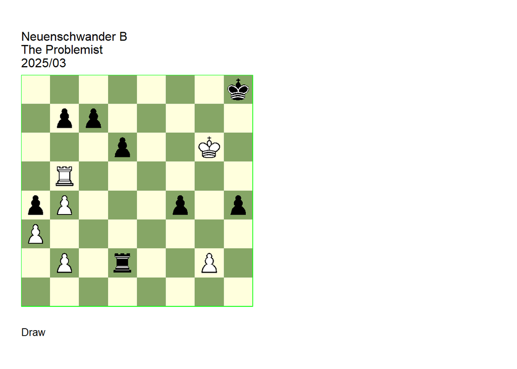

GBR: =0400.46g6h8 FEN: 7k/1pp5/3p2K1/1R6/pP3p1p/P7/1P1r2P1/8 w - - 0 1

**1. g3!!** (1. Kf7? d5 2. Rxb7 Rxg2 -+) (1. g4? Kg8! 2. Rxb7 Kf8 3. Kf6 Ke8 4. Ke6 Re2+ -+) (1. Rg5? Kg8! 2. Kf6+ Kf8 -+) **1… Rg2** (1… Rd3 2. g4 Kg8 3. Rxb7 Kf8 4. Kf6 Re3 5. Rb8+ Re8 6. Rb5 Re7 7. Rb8+ Re8 8. Rb5 =) ( 1… Kg8 2. Rxb7 Kf8 3. Kf6 Ke8 4. gxf4) **2. Kf7 c5 3. bxc5 d5** (3… fxg3 4. cxd6 Rf2+ 5. Ke7 g2 6. d7 Re2+ 7. Kf7 Rf2+ 8. Ke7 =) **4. Rb4! Rxg3** (4… hxg3 5. c6! (5. Rxf4? Rf2 -+) 5… Rh2 (5… bxc6?? 6. Kg6 +-) 6. cxb7 Rh7+ 7. Kg6 Rg7+ 8. Kh6 Rh7+ 9. Kg6 =) **5. Rxf4 Rg7+ 6. Kf8 h3 7. Rh4+ Rh7 8. Rg4 Rh5 9. Kf7! Rf5+** (9… h2 10. Rg8+ Kh7 11. Rg7+ Kh6 12. Rg6+ Kh7) **10. Ke6!** (10. Kg6? Rf3 11. Rh4+ Kg8 12. Kg5 d4 13. Rxd4 h2 14. Rh4 Rf2) **10… Rh5** ( 10… Rf3 11. Rh4+ (11. Kxd5? Rf7 -+) 11… Kg7 12. Kxd5 Kf6 13. Ke4 Kg5 14. Rh8 Rb3 15. Rg8+ =) **11. Kf7 Rh7+ 12. Kf8 Rh5 13. Kf7 Rf5+ 14. Ke6** positional draw **1/2-1/2**.

## Sinfonie Scacchhistiche (published)

File: Neuenschwander-2025-Sinfonie.pgn

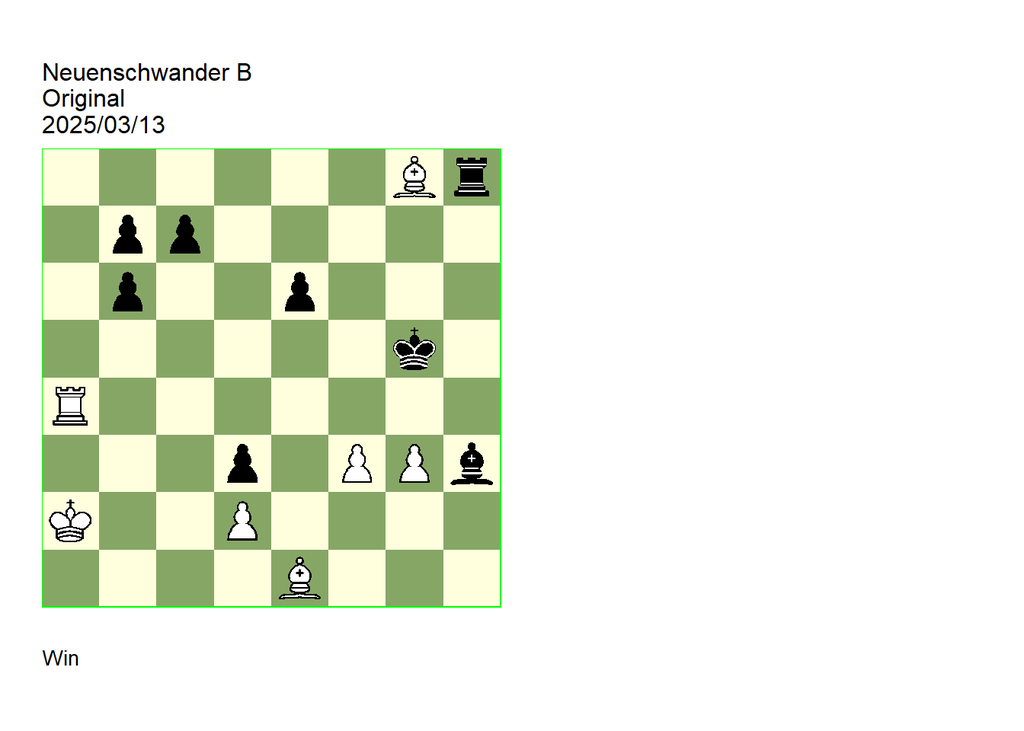

GBR: +0450.35a2g5 FEN: 6Br/1pp5/1p2p3/6k1/R7/3p1PPb/K2P4/4B3 w - - 0 1

**1. Ra8** (1. Rh4? Rxh4 2. gxh4+ Kg6) **1… Kf6 2. Re8** (2. Bf2 e5 3. g4 Kg7 4. Bg3 Rxg8 5. Bxe5+ Kf7) **2… Kg7 3. Bf7! Rh6 4. Re7! Kf8 5. Rd7!** (5. Rxc7? Rh7) **5… Rh7 6. Be8! Rh6 7. Rd8! Ke7 8. Rc8! Rh8 9. Bd7!** (9. Rxc7+? Kd8 10. Rxb7 Rxe8) **9… Rh5 10. Rxc7!** (10. Ba4? Ra5 11. Kb3 b5) **10… Kd8** (10… Kd6 11. Rxb7 Rh7 12. Bc6) **11. Rxb7! Rh7 12. Bc6!** (12. Bc8 loss of time 12… Rh5 13. Bd7 (13. Rb8? Ra5+ 14. Kb3 Kc7) 13… Rh7 . Four unpinnings in a sequence of ten consecutive minimal-length moves by white rook and bishop. ) **1-0**.

# Awards

## Suomen Shakki 100-JT

File: Neuenschwander-2024-SuomenShakki100JT.pgn

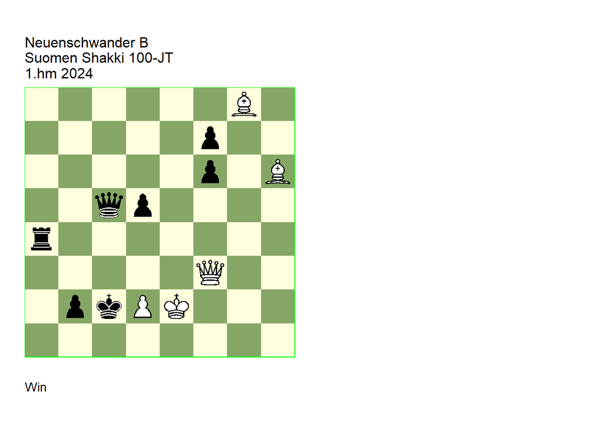

GBR: +4320.14e2c2 FEN: 6B1/5p2/5p1B/2qp4/r7/5Q2/1pkPK3/8 w - - 0 1

**1. Qd3+** (1. Bh7+? Re4+ 2. Bxe4+ dxe4 3. Qxe4+ Kb3 =) **1… Kc1 2. Bh7 Re4+** ( 2… Qe7+ **main** 3. Be3 Re4 4. Qxd5! b1=Q 5. Bxe4 Qbxe4 (5… Qbb4 6. Qc6+ Kb2 7. Qc2+ Ka3 8. d3! +/-) 6. Qxe4 Qxe4 7. d3+! (theme) 7… Kc2 8. dxe4 +/-) **3. Qxe4! Qb5+** (3… dxe4 **main** 4. d4+! (theme) 4… Kb1 5. dxc5 +/- (5. Bxe4+? Qc2+ -/+) ) **4. Qc4+!!** (4. d3+? Kb1! (4… Kc2 5. Qc4+!) 5. Qc4 Qe8+! -/+) **4… dxc4** (4… Qxc4+ **main** 5. d3+! (theme) 5… Kc2 6. dxc4+ +/-) **5. d3+!** (5. d4+? Qg5! -/+) **5… Kc2 6. dxc4+!** (theme) **6… Kb3 7. cxb5** White bishop-pawn batteries win the black queen on four different squares. **1-0**.

> Pauli Perkonoja: “Quite an effective display of bishops’ brilliance, with the white queen providing support. In the side variation, even Black’s two queens cannot save him from destruction.”

## Problem Paradise 2024

File: Neuenschwander-2024-ProblemParadise105.pgn

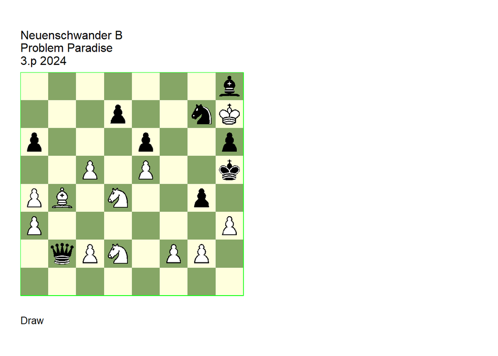

**1. c6!** (1. Ne4? Qxd4 -+) **1… dxc6** (1… gxh3 2. c7 hxg2 3. N2f3) **2. Ne4 Nf5** (2… Qxd4? 3. Ng3+ Kg5 4. Be7+ Kf4 5. Ne2+) **3. Nxf5 exf5 4. Ng3+ Kg5 5. h4+ Kf4 6. Bd6 Bxe5** (6… Qb7+ 7. Kxh8 Qc8+ 8. Kg7 Qd7+ 9. Kg6 Qe8+ 10. Kg7 = ) **7. Bf8 Qb7+ 8. Kg6 Bc7 9. Bg7!** Threatens perpetual check with Ne2+ and Nc3+ etc. **9… Ba5 10. Ba1!** Threatens perpetual check with Nh5+ and Nf6+ etc. **10… Bd8 11. Bh8!** (11. Bg7? Qe7 12. Nh5+ Ke4 13. Nf6+ Kd4 14. Ng8+ Qxg7+ 15. Kxg7 Bxh4 -+) **11… Ba5** (11… Qe7 12. Nh5+ Ke4 13. Nf6+ Kd4 (13… Qxf6+ 14. Bxf6 Bxf6 15. Kxf6 =) 14. Ng8+ =) **12. Ba1! Bd8 13. Bh8!** positional draw **1/2-1/2**.

File: Neuenschwander-2024-ProblemParadise108.pgn

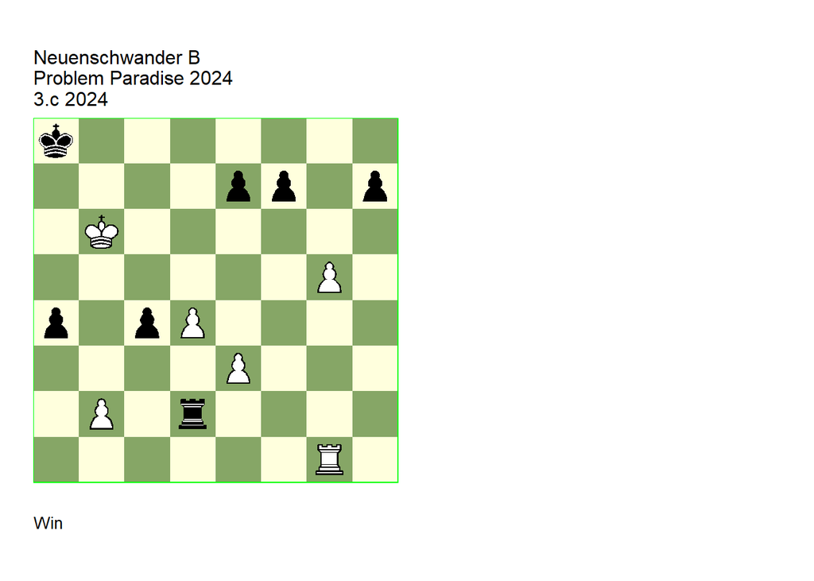

GBR: +0400.45b6a8 FEN: k7/4pp1p/1K6/6P1/p1pP4/4P3/1P1r4/6R1 w - - 0 1

**1. b4!** (1. b3? Rb2! =) **1… cxb3** (1… Rb2 2. b5 +-) **2. g6! b2** (2… fxg6 3. Rf1 +-) (2… hxg6 3. Rh1 +-) **3. gxf7** (3. gxh7? b1=Q+ 4. Rxb1 Rh2 5. Kc7 (5. Ra1 Kb8 =) 5… Ka7 =) (3. g7? b1=Q+ 4. Rxb1 Rg2 5. Kc7 (5. Ra1 Kb8 =) 5… Ka7 =) **3… b1=Q+ 4. Rxb1 Rf2 5. e4!** (5. Kc7? Rxf7 =) (5. d5? Rxf7) **5… Rxf7 6. e5 e6 7. Kc6 1-0**.

> Martin Minski: “Who would have found the first two pawn sacrifices in this rook endgame?”

# Comments and revisions

## Prize winners

### Nestorescu +0431.11b4g8 (1983). Correction

Date: March 10, 2025

File: Nestorescu1983b.pgn

Shifting the position one file to the left saves the study because the cook is now no longer working due to a theoretically drawn 0130.10 ending.

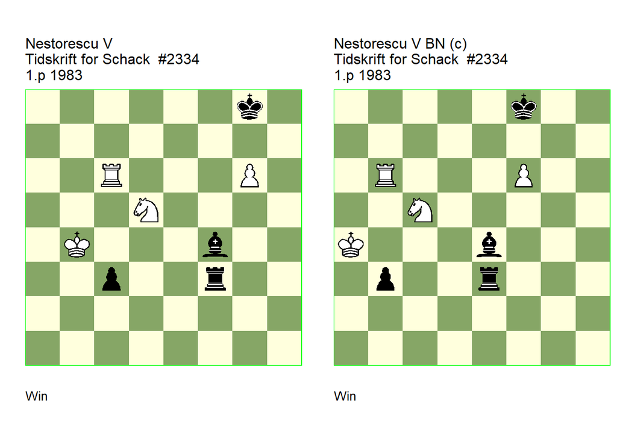

GBR: +0431.11b4g8 U2 FEN: 6k1/8/2R3P1/3N4/1K3b2/2p2r2/8/8 w - - 0 1

Tidskrift for Schack=7 Tidskrift for Schack/9 (EG#05945). U2: Pallier=A HHdbVI 9-2-2019. **1. Ne7+! Kh8** (1… Kf8 **main** 2. Nf5! (2. Rc8+? Kxe7 3. g7 Rg3) 2… Bc7! (2… Bd6+ 3. Nxd6 c2 (3… Rf1 4. Kb3 c2 5. Kxc2) (3… Rf6 4. Rc8+ Kg7 5. Ne8+) (3… Kg7 4. Ne8+ Kg8 5. Rxc3) 4. Rxc2 Rf4+ 5. Rc4! Rxc4+ 6. Nxc4 Kg7 7. Ne5) 3. Rf6+ Kg8 4. Ne7+ (4. Kb3! **cook** AP 4… Bd6 ( 4… c2+ 5. Kxc2 Rc3+ 6. Kd1 Be5 7. Re6) (4… Rf4 5. Rf7) 5. Ne7+ Bxe7 6. Rxf3 Bd6) 4… Kh8 5. Rxf3 Bd6+ 6. Kxc3 Bxe7 7. Rf7) (1… Kg7 2. Nf5+) **2. Rc8+** (2. Nf5? Bc7! 3. Rf6 Bd6+! 4. Kb3 Rxf5 5. Rxf5 Kg7 6. Rg5 (6. Rb5 Bf4 7. Rb6 Bg5) 6… Be7 7. Rg2 Bf6) **2… Kg7 3. Nf5+!** (3. Rg8+? Kf6 4. Nd5+ Kg5 5. Nxf4 Rxf4+ 6. Kxc3 Kh6) **3… Kf6 4. g7 Bd6+** (4… c2 5. Rf8+ Ke5 6. g8=Q Bd2+ 7. Kb5 c1=Q 8. Qg7+) **5. Kb3! c2+ 6. Kxc2 Rf2+ 7. Kd3! Rg2 8. Rf8+ Ke5 9. Nd4! Rxg7 10. Rf5# 1-0**.

GBR: +0431.11a4f8 (c) FEN: 5k2/8/1R3P2/2N5/K3b3/1p2r3/8/8 w - - 0 1

correction: Neuenschwander=B beatochess 10/03/2025 **1. Nd7+! Kg8** (1… Ke8 **main** 2. Ne5 Bb7 3. Re6+ Kf8 4. Nd7+ (4. Ka3? Bc6 5. Nd7+ Bxd7 6. Rxe3 Bc6 7. Re7 Bd5 =) 4… Kg8 5. Rxe3 Bc6+ 6. Kxb3 Bxd7 7. Re7 Bc6 8. Kc4 Ba4 9. Rb7 ) **2. Rb8+ Kf7 3. Ne5+ Ke6 4. f7 Bc6+ 5. Ka3 b2+ 6. Kxb2 Re2+ 7. Kc3 Rf2 8. Re8+ Kd5 9. Nc4 Rxf7 10. Re5# 1-0**.

### Kasparyan =0560.12d4h2 (1983). Cook

Date: March 11, 2025

File: Kasparyan1983a.pgn

**2…Be5+ 3. Kc2 Rg6!** seems to be winning for Black.

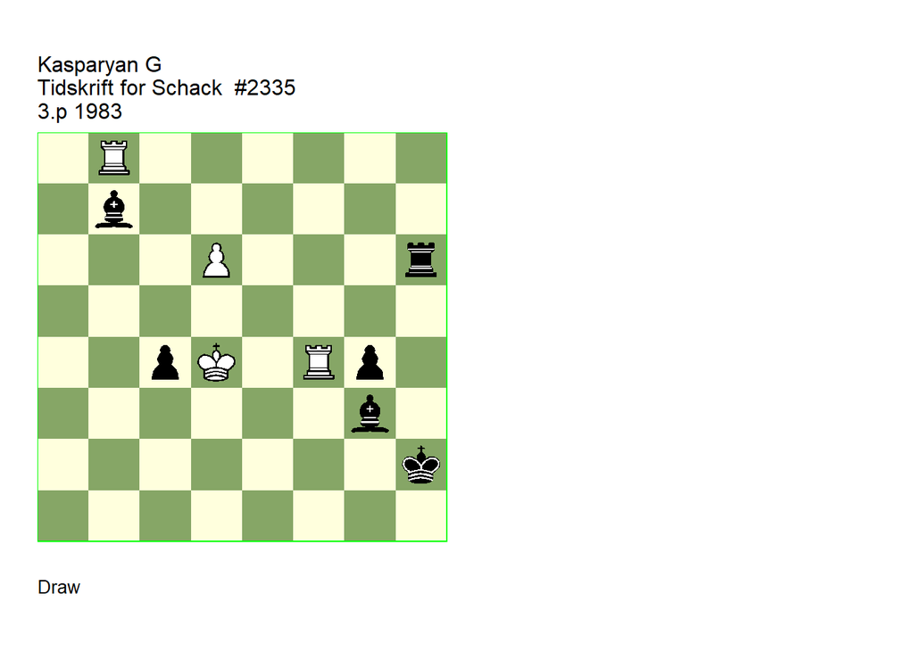

GBR: =0560.12d4h2 U3 FEN: 1R6/1b6/3P3r/8/2pK1Rp1/6b1/7k/8 w - - 0 1

Tidskrift for Schack=7 Tidskrift for Schack/9 (EG#05948). U3: Neuenschwander=B beatochess 11/03/2025. **1. Rxg4 Rxd6+ 2. Kc3 Rd3+** (2… Be5+ 3. Kc2 Rg6! **cook** **BN** 4. Rxg6 Be4+) **3. Kxc4 Ba6+ 4. Rb5 Rd1 5. Kc5 Bf2+ 6. Kb4 Rb1+ 7. Ka5 Bxb5 8. Rg2+ Kxg2 1/2-1/2**.

### Silaev +4800.22f8h6 (1983). Correction

Date: March 16, 2025

File: Silaev1983a.pgn

With the additional pawns on the a-line, the Q ending after 5. Rb6 is no longer winning.

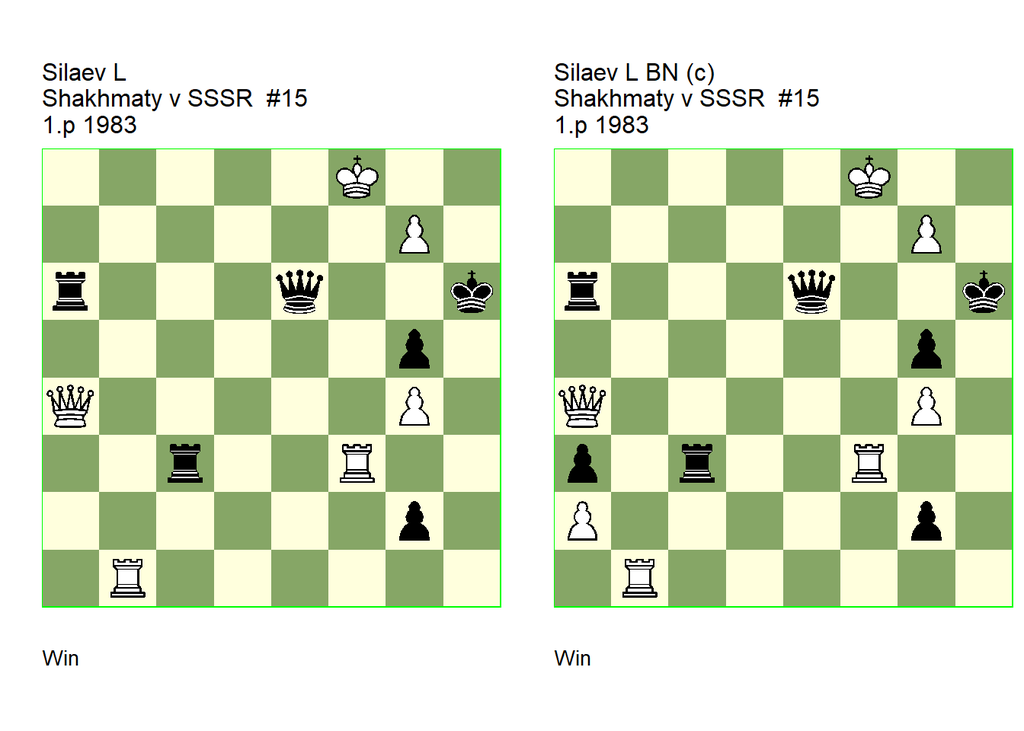

GBR: +4800.22f8h6 U2 FEN: 5K2/6P1/r3q2k/6p1/Q5P1/2r2R2/6p1/1R6 w - - 0 1

Shakhmaty v SSSR/4 (EG#05986). U2: (HHdbII#45328 2000). **1. Rh3+!** (1. g8=N+? Kg6 2. Ne7+ Kh7 3. Rxc3 Qh6+!) **1… Rxh3** (1… Kg6 2. Qe4+ Qxe4 3. g8=Q+ Kf6 4. Qg7+ Ke6 5. Qe7+ Kd5 6. Rd1+) **2. g8=N+!** (2. g8=Q? Rf3+) **2… Qxg8+** ( 2… Kg6 3. Qc2+) (2… Kh7 3. Rb7+ Kh8 4. Qd4+) **3. Kxg8 Rg6+** (3… Rxa4 4. Rb6#) **4. Kh8!** (4. Kf7? Rf3+ 5. Ke7 (5. Ke8 Re6+ (5… Rg8+? 6. Ke7 Rg7+ ( 6… Rf1 7. Rb6+) 7. Ke6 Rf1 8. Qe8 Rc7 (8… Rg6+ 9. Ke5 Kh7 10. Qd7+ Rg7 11. Qd3+) 9. Qh5+ Kg7 10. Qxg5+) (5… Rf1? 6. Qb3 Rxb1 (6… g1=Q 7. Qh3+ Kg7 8. Rb7+ Kf6 9. Qc3+ Ke6 10. Qc4+ Kd6 11. Rd7+ Ke5 12. Rd5+ Kf6 13. Qc3+) 7. Qxb1 Rc6 8. Qg1 Rc2 9. Kf8) 6. Kd7 Rf1 7. Qa8 g1=Q 8. Qh8+ Kg6 9. Qg8+ Kh6 10. Qxe6+ Kg7 11. Qe5+ Kh7 12. Rxf1 Qxf1 13. Qf5+ Qxf5+ 14. gxf5 g4 15. f6 g3 16. f7 g2 17. f8=Q g1=Q) 5… Rf1 6. Qe8 Kh7) **4… Rf6** (4… Re6 5. Qe4) (4… Rd3 5. Qe8) **5. Qe8!** (5. Qb4? g1=Q 6. Rxg1 Kg6+ 7. Kg8 Rh8+ 8. Kxh8 Rf8+ 9. Qxf8 ) (5. Rb6! **cook** 5… Kg6+ 6. Kg8 Rxb6 7. Qa7 Rb8+ 8. Qxb8 Rh8+ 9. Kxh8 g1=Q 10. Qd6+ Kf7 11. Qd7+ Kf8 12. Qf5+ Ke8 13. Qxg5) **5… g1=Q 6. Rb7 Rf8+ 7. Qxf8+ Kg6+ 8. Kg8 Rh8+ 9. Kxh8 Qh1+ 10. Qh6+!** (10. Kg8? Qh8+ 11. Kxh8) **10… Qxh6+ 11. Kg8! Kf6 12. Rb6+ 1-0**.

GBR: +4800.33f8h6 (c) FEN: 5K2/6P1/r3q2k/6p1/Q5P1/p1r2R2/P5p1/1R6 w - - 0 1

correction: Neuenschwander=B beatochess 16/03/2025. **1. Rh3+!** (1. g8=N+? Kg6 2. Ne7+ Kh7 3. Rxc3 Qh6+!) **1… Rxh3** (1… Kg6 2. Qe4+ Qxe4 3. g8=Q+ Kf6 4. Qg7+ Ke6 5. Qe7+ Kd5 6. Rd1+) **2. g8=N+!** (2. g8=Q? Rf3+) **2… Qxg8+** (2… Kg6 3. Qc2+) (2… Kh7 3. Rb7+ Kh8 4. Qd4+) **3. Kxg8 Rg6+** (3… Rxa4 4. Rb6#) **4. Kh8!** (4. Kf7? Rf3+ 5. Ke7 (5. Ke8 Re6+ (5… Rg8+? 6. Ke7 Rg7+ (6… Rf1 7. Rb6+) 7. Ke6 Rf1 8. Qe8 Rc7 (8… Rg6+ 9. Ke5 Kh7 10. Qd7+ Rg7 11. Qd3+) 9. Qh5+ Kg7 10. Qxg5+) (5… Rf1? 6. Qb3 Rxb1 (6… g1=Q 7. Qh3+ Kg7 8. Rb7+ Kf6 9. Qc3+ Ke6 10. Qc4+ Kd6 11. Rd7+ Ke5 12. Rd5+ Kf6 13. Qc3+) 7. Qxb1 Rc6 8. Qg1 Rc2 9. Kf8) 6. Kd7 Rf1 7. Qa8 g1=Q 8. Qh8+ Kg6 9. Qg8+ Kh6 10. Qxe6+ Kg7 11. Qe5+ Kh7 12. Rxf1 Qxf1 13. Qf5+ Qxf5+ 14. gxf5 g4 15. f6 g3 16. f7 g2 17. f8=Q g1=Q) 5… Rf1 6. Qe8 Kh7) **4… Rf6** (4… Re6 5. Qe4) (4… Rd3 5. Qe8) **5. Qe8!** (5. Qb4? g1=Q 6. Rxg1 Kg6+ 7. Kg8 Rh8+ 8. Kxh8 Rf8+ 9. Qxf8) (5. Rb6? 5… Rxb6 6. Qa7 Kg6+ 7. Kg8 Rb8+ 8. Qxb8 Rh8+ 9. Kxh8 g1=Q) **5… g1=Q 6. Rb7 Rf8+ 7. Qxf8+ Kg6+ 8. Kg8 Rh8+ 9. Kxh8 Qh1+ 10. Qh6+!** (10. Kg8? Qh8+ 11. Kxh8) **10… Qxh6+ 11. Kg8! Kf6 12. Rb6+ 1-0**.

### Nadareishvili =3036.11a1g4 (1984). Comment

Date: March 17, 2025

File: Nadareishvili1984a.pgn

**8… Ke1!** cooks the first study. Therefore the second study is a correction.

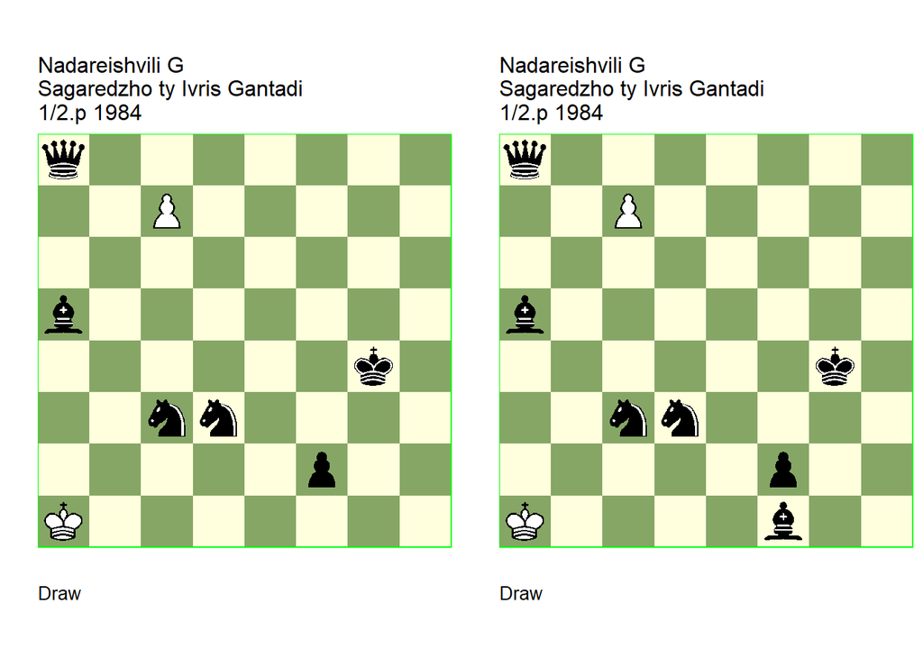

GBR: =3036.11a1g4 U3 FEN: q7/2P5/8/b7/6k1/2nn4/5p2/K7 w - - 0 1

(EG#06009). U3: Neuenschwander=B beatochess 17/03/2025. **1. c8=Q+ Kf3** (1… Qxc8) **2. Qg4+** (2. Qxa8+? Ne4 3. Qf8+ Nf4) (2. Qf8+? Ke2 3. Qf3+ Ke1 4. Qh1+ Kd2 5. Qh6+ Nf4!) **2… Ke3 3. Qf3+! Kd4** (3… Kxf3) (3… Kd2 4. Qe3+! Kc2 5. Qd2+ Kb3 6. Qc2+) **4. Qe3+** (4. Qg4+? Ne4) (4. Qf6+? Ne5) **4… Kc4** (4… Kd5 5. Qd4+ Kc6 6. Qd7+ Kc5 7. Qd4+ Kb5 8. Qc4+) **5. Qd4+ Kb3 6. Qc4+ Kc2 7. Qb3+ Kd2** (7… Kc1 8. Qc2+ Kxc2) **8. Qc2+ Ke3** (8… Ke1! **cook** **BN** ) **9. Qd2+ Kd4 10. Qe3+ Kxe3 1/2-1/2**.

GBR: =3066.11a1g4 (v) FEN: q7/2P5/8/b7/6k1/2nn4/5p2/K4b2 w - - 0 1

**1. c8=Q+! Kf3! 2. Qg4+!** (2. Qh3+? Ke2! 3. Qxf1+ (3. Qf3+ Ke1!) 3… Kd2!) **2… Ke3 3. Qf3+! Kd4! 4. Qe3+ Kc4 5. Qd4+ Kb3! 6. Qc4+ Kc2!** ( 6… Ka3 7. Qb3+ Kxb3) **7. Qb3+ Kd2!** (7… Kc1 8. Qc2+ Kxc2) **8. Qc2+ Ke3!** ( 8… Ke1 9. Qd2+ Kxd2) **9. Qd2+ Kd4 10. Qe3+ 1/2-1/2**.

### Cortlever +0730.51e6h8 (1981). Dual, cook

Date: March 17, 2025

File: Cortlever1981a.pgn

There seems to be no win after **1… Rd8!**. On the other hand, **12. Kd7** seems to be (only) a dual because the position after move 14 is identical to the one in the mainline.

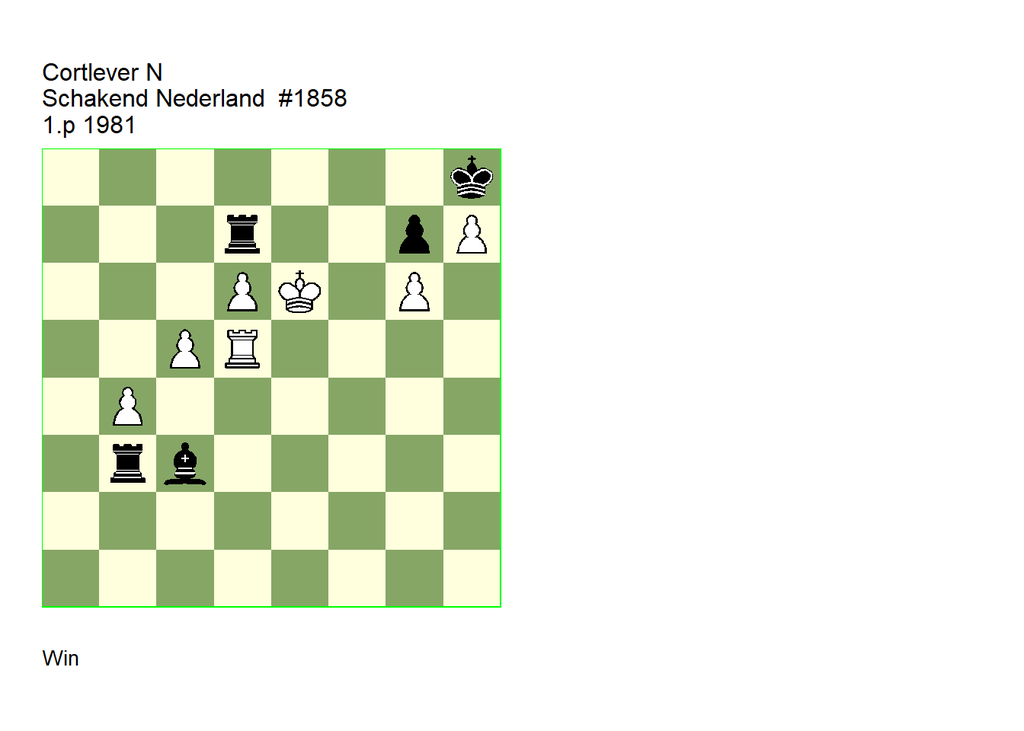

GBR: +0730.51e6h8 U2 U3 FEN: 7k/3r2pP/3PK1P1/2PR4/1P6/1rb5/8/8 w - - 0 1

Schakend Nederland/2 1982 (EG#06059). U2: Campioli=M HHdbII#43529 24-3-1999. U3: Neuenschwander=B beatochess 17/03/2025. **1. c6** (1. Kxd7? Be5! 2. Rxe5 ( 2. c6 Bxd6 3. Rxd6 Rd3) 2… Re3 3. Rf5 Re7+ 4. Kc6 Rc7+) **1… Bxb4** (1… Rxb4 2. Kxd7) (1… Be5 2. cxd7 Bf6 3. Re5! Rf3 4. Kd5 Rd3+ 5. Kc6 Rxd6+ 6. Kxd6 Bxe5+ 7. Ke7 Bf6+) (1… Rd8! **cook** **BN** 2. c7 Bf6 3. cxd8=Q+ Bxd8 4. Rf5 Be7) **2. c7!** (2. cxd7? Re3+ 3. Kf7 Ba5 4. Rc5 Bd8 5. Rc8 Re7+ 6. Kf8 Rxd7 7. Rc6 Rxd6 8. Rxd6 Be7+ 9. Kxe7) **2… Rxd6+ 3. Rxd6 Re3+ 4. Kd5** (4. Kf7? Re7+ 5. Kxe7 Bxd6+ 6. Kxd6) **4… Re8 5. Rd8 Bf8! 6. Kc6 Re6+** (6… Rxd8 7. cxd8=N Bb4 8. Nf7#) **7. Kb7 Rb6+ 8. Kc8 Rb8+ 9. Kd7 Rc8** (9… Ra8 10. Rb8 Rxb8 11. cxb8=N) **10. Ke6!** (10. Ke8? Rxc7) (10. Kc6? Rxc7+) **10… Ra8 11. Rb8 Ra6+ 12. Kf7** (12. Kd7! **cook** MC 12… Rd6+ 13. Ke8 Re6+ 14. Kxf8) **12… Rf6+ 13. Ke8 Re6+ 14. Kxf8 Re8+ 15. Kf7 1-0**.

### Rinder =0130.13h5g8 (1983). Cook

Date: March 18, 2025

File: Rinder1983a.pgn

**8. Rd7!** cooks the study.

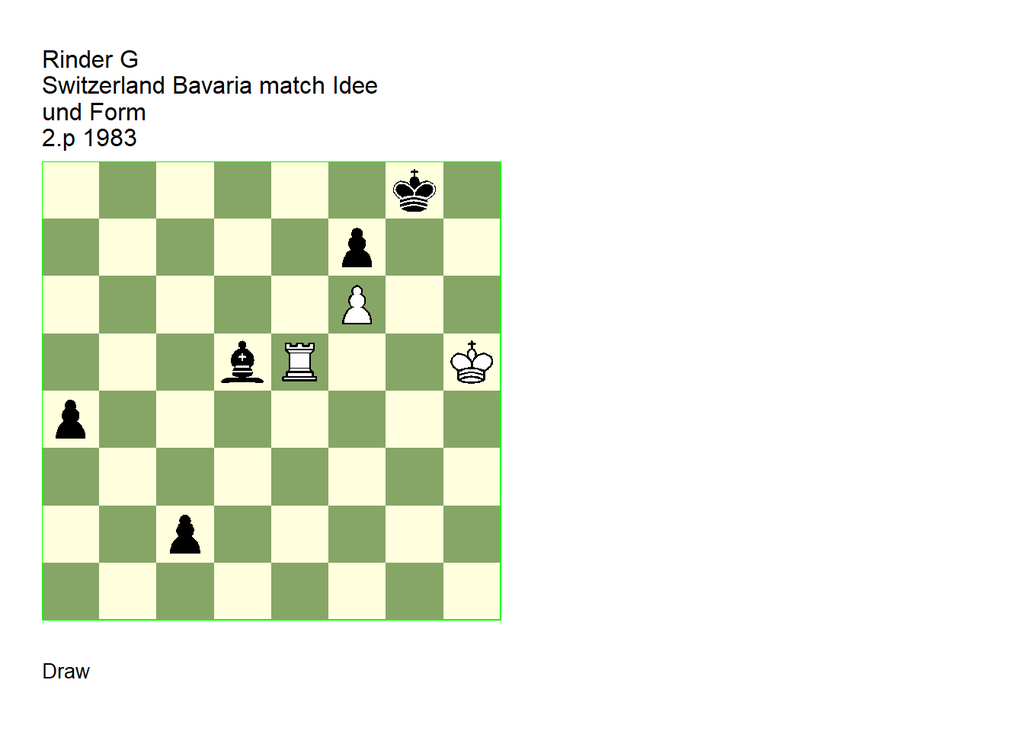

GBR: =0130.13h5g8 U2 FEN: 6k1/5p2/5P2/3bR2K/p7/8/2p5/8 w - - 0 1

(EG#06097). U2: Neuenschwander=B 18/03/2025. **1. Rg5+** (1. Re1? Ba2 2. Re8+ ( 2. Kh6 Kf8 3. Ra1 Bb1 4. Rxa4 c1=Q+) 2… Kh7 3. Rc8 Bb3) **1… Kh7 2. Rg7+ Kh8 3. Rg1 Bf3+ 4. Kh6 Bd1 5. Rg5 c1=R** (5… c1=Q) **6. Rd5** (6. Rc5? Rc2) **6… Rc8 7. Rxd1 Ra8 8. Rd5** (8. Rd7! **cook** **BN** 8… Kg8 (8… a3 9. Rxf7) 9. Rd5 Kf8 10. Kh7 Ke8 11. Kg7 a3 12. Re5+ Kd7 13. Re1) **8… a3 9. Ra5 Rxa5 1/2-1/2**.

### Kozdon =3357.25a4a8 (1983). Cook, correction

Date: March 19, 2025

File: Kozdon1983a.pgn

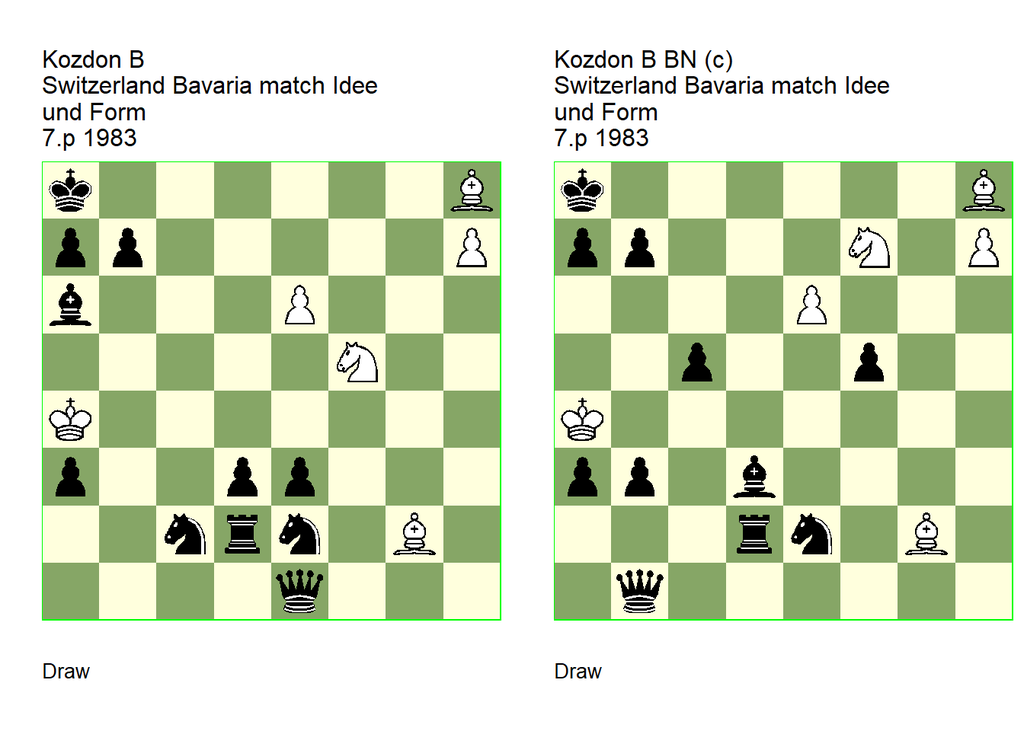

GBR: =3357.25a4a8 U3 FEN: k6B/pp5P/b3P3/5N2/K7/p2pp3/2nrn1B1/4q3 w - - 0 1

(EG#06102). U3: Garcia=M HHdbV#30762 24-9-2011. **1. Bc3** (1. e7? Bb5+) (1. Bg7? Bb5+ 2. Ka5 Rd1+) **1… Nxc3+** (1… Bb5+ 2. Ka5 a6 3. h8=Q+ Ka7 4. Qd8 Bc6 5. Qb6+) **2. Ka5 Qh1 3. Bxh1 Rh2 4. e7** (4. Nh6? Rh5+) **4… Bb5 5. Nh6** (5. Nh4? Rxh4 6. Bc6 Ra4#) (5. Bc6? Bxc6 6. Nh6 Rh5+) **5… Rxh6** (5… Rh5! **cook** MG ) **6. Bc6 Bxc6** (6… bxc6 7. e8=Q+ Kb7 8. Qd7+) (6… a6 7. e8=Q+ Ka7 8. Qd8 Rxc6 9. h8=Q) **7. h8=Q+** (7. e8=Q+? Bxe8 8. h8=Q b6+ 9. Ka6 Nb4#) **7… Rxh8 8. e8=Q+ Bxe8** (8… Rxe8) **1/2-1/2**.

GBR: =3354.26a4a8 (c) FEN: k6B/pp3N1P/4P3/2p2p2/K7/pp1b4/3rn1B1/1q6 w - - 0 1

correction: Neuenschwander=B beatochess 19/03/2025. **1. Bc3!** (1. Be5? Bb5+ 2. Ka5 (2. Kxb5 Qd3+) 2… Qe1 3. h8=Q+ Rd8+) (1. Bd4? Nc3+! 2. Bxc3 (2. Ka5 Qh1 3. Bxh1 Rh2 4. e7 Bb5) 2… Bb5+ 3. Ka5) **1… Qh1** (1… Nxc3+ leads to the **main** line ) (1… a6 2. h8=Q+ Ka7 3. Bxb7 Nxc3+ 4. Ka5 Kxb7 5. Qg7) **2. Bxh1 Nxc3+ 3. Ka5 Rh2 4. e7 Bb5 5. Nh6! Rxh6 6. Bc6! Bxc6 7. h8=Q+ Rxh8 8. e8=Q+ Rxe8 1/2-1/2**.

### Pervakov +0116.23e1h1 (1985). Cook, correction

Date: March 21, 2025

File: Pervakov1985a.pgn

The white advantage in the Q-nn ending after **10… Nb3!** etc. does not seem to be sufficient for a win. Moreover, **10. Kg3** does not win due to **10…Nd2** (not Ne5).

In the correction, the play after **10. Kg3** (now the mainline) is quite subtle although similar to the original study.

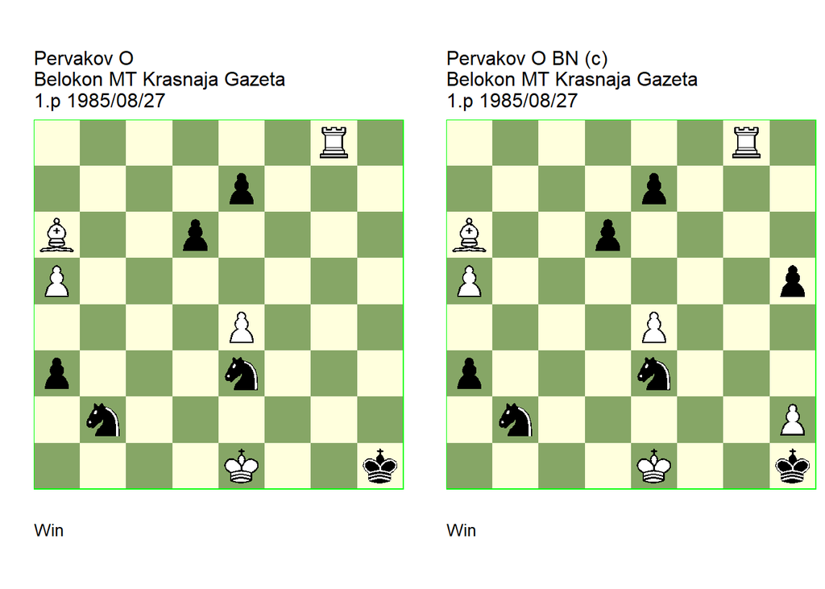

GBR: +0116.23e1h1 U3 FEN: 6R1/4p3/B2p4/P7/4P3/p3n3/1n6/4K2k w - - 0 1

(EG#06165). U3: Neuenschwander=B beatochess 21/03/2025. **1. Rc8 a2 2. Rc1 a1=Q! 3. Rxa1 Nc2+ 4. Kf2+** (4. Kf1? Nxa1 5. Bb5 Nb3 6. a6 Nc4 7. Bxc4 Nd2+ 8. Ke2 Nxc4 9. a7 Nb6 10. Kd3 Kg2 11. Kc3 Kg3 (11… Kf3? 12. Kb4 e6 13. Kb5 Na8 14. Kc6 d5 15. exd5 exd5 16. Kb7 d4 17. Kxa8 d3 18. Kb8 d2 19. a8=Q+) 12. Kb4 e6 13. Kb5 Na8 14. Kc6 d5 15. exd5 exd5 16. Kxd5 Kf4) (4. Ke2+? Nxa1 5. Bb5 Nb3 6. a6 Nd4+) **4… Nxa1 5. Bb5! Nd1+ 6. Kg3!** (6. Ke1? Nc3 7. Bc6 Nc2+ 8. Kd2 Nb4! 9. Kxc3 Nxc6 10. a6 e6!) **6… Nc3 7. Bc6! Ne2+ 8. Kh4!** (8. Kg4? Nd4 9. Bd7 Nac2 10. a6 Ne3+ 11. Kg5 Nc4) **8… Nd4** (8… Nf4 9. Bd7 Ng6+ 10. Kg3 Nf8 11. Bc8!) **9. Bd7! Nf3+ 10. Kh5** (10. Kg3? Ne5 (10… Nd2! only move to draw: **BN** ) 11. Bb5 Ng6! 12. Kg4 (12. a6 +- **BN** ) 12… Nf8 13. Kf5 Nb3 14. a6 Nd4+) **10… Ne5** (10… Nb3! **cook** **BN** 11. a6 Nc5 12. a7 Nxd7 13. a8=Q Kg2) **11. Bb5! Nb3 12. a6 Nd4 13. a7 Nxb5 14. a8=Q 1-0**.

GBR: +0116.34e1h1 (c) FEN: 6R1/4p3/B2p4/P6p/4P3/p3n3/1n5P/4K2k w - - 0 1

correction: Neuenschwander=B beatochess 21/03/2025. **1. Rc8 a2 2. Rc1 a1=Q 3. Rxa1 Nc2+ 4. Kf2+ Nxa1 5. Bb5 Nd1+ 6. Kg3 Nc3 7. Bc6 Ne2+ 8. Kh4** (8. Kf2? Nf4 9. a6 Ne6) **8… Nd4** (8… Nc2 9. a6 Nb4 10. a7 Nxc6 11. a8=Q Ncd4 12. Qf8 Kxh2 13. Qf2+ Kh1 14. Kxh5) **9. Bd7 Nf3+ 10. Kg3** (10. Kxh5? Nb3 11. a6 Nc5 12. a7 Nxd7 13. a8=Q Kxh2) (10. Kh3? Ne5 11. Bb5 Nf3 12. a6 Ng5+) **10… Ne5** (10… Nd2 11. a6 Nc4 12. Be6 Nb6 13. h4) **11. Bb5 Nb3 12. a6 Nd4 13. a7** (13. Be8? h4+ 14. Kxh4 Nc4 15. Kg3 Ne2+ 16. Kf2 Nc3) **13… Nxb5 14. a8=Q 1-0**.

### Ivanov =0470.11h1f6 (1985). Comment

Date: March 21, 2025

File: Ivanov1985a.pgn

The line after 1… Bd3 is missing but quite beautiful as well.

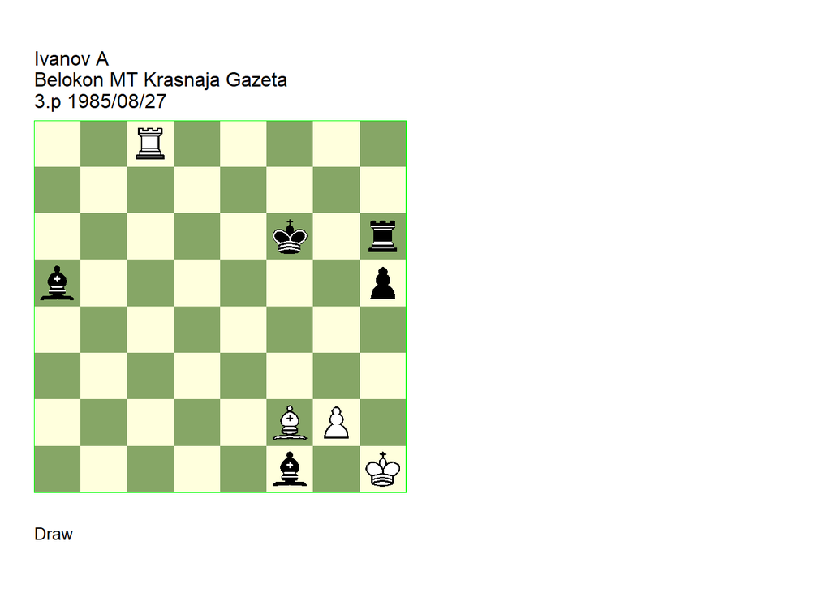

GBR: =0470.11h1f6 FEN: 2R5/8/5k1r/b6p/8/8/5BP1/5b1K w - - 0 1

(EG#06167). Comment Neuenschwander=B beatochess 21/03/2025. **1. Rc1** (1. Rc5? Bd2) **1… Be2** (1… Bd3 **main** ? **BN** 2. Rc5 Bb4 3. Rc6+ Kg7 4. Bd4+ Kh7 5. Rc7+ Kg8 6. Rg7+ Kf8 7. Rg3 Bg6 8. Be3) **2. Rc5 Bb4** (2… Bd8 3. Bh4+) **3. Rc6+ Kg7 4. Bd4+ Kh7 5. Rc7+ Kg8 6. Rg7+ Kf8 7. Rb7 Be7 8. Bg7+ Kxg7 9. Rxe7+ 1/2-1/2**.

### Hlinka =0130.21g7c8 (1984). Cook

Date: April 1, 2025

File: Hlinka1984a.pgn

**9. Rf7!** cooks the study.

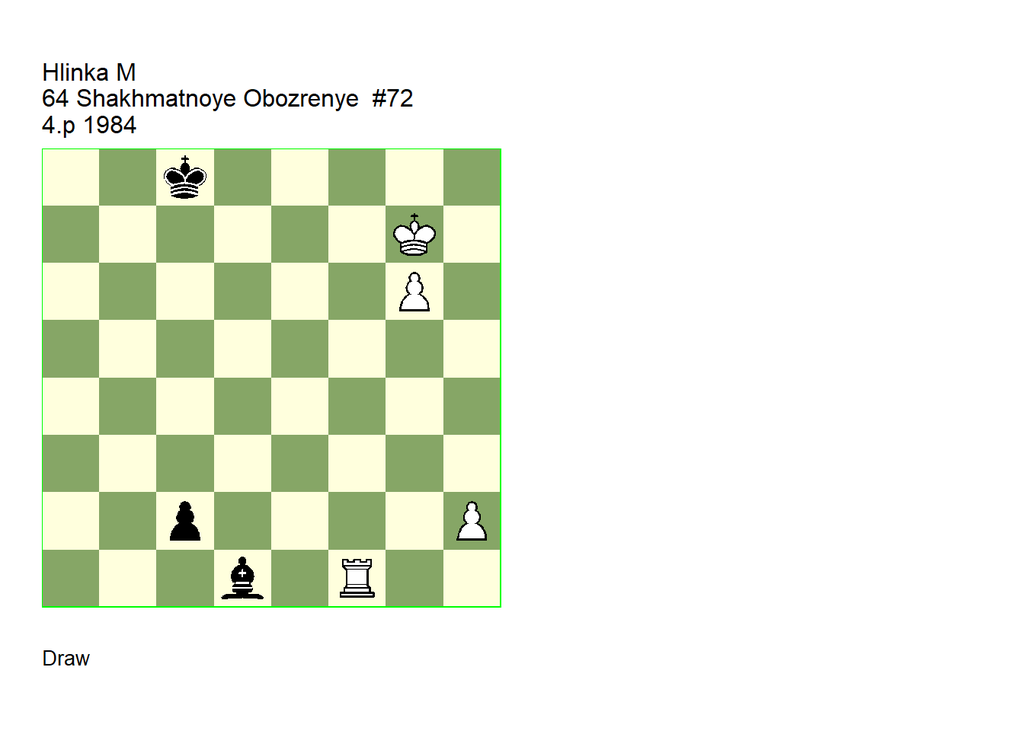

GBR: =0130.21g7c8 FEN: 2k5/6K1/6P1/8/8/8/2p4P/3b1R2 w - - 0 1

64 Shakhmatnoye Obozrenye=23(718) 64 Shakhmatnoye Obozrenye/12 (EG#06194). U2: Neuenschwander=B beatochess 01/04/2025. **1. Rf8+** (1. Kh8? c1=Q 2. g7 Qh6+!) **1… Kc7 2. Rf7+ Kb6 3. Rf6+ Kb5 4. Rf5+!** (4. Kh8? c1=Q 5. g7 Bb3!) **4… Kb4 5. Rf4+ Kb3** (5… Kc3 6. Rf6! Be2 7. Kh8 c1=Q 8. g7 Bc4 9. Rc6 Kb3 10. g8=Q!) **6. Kh8! c1=Q 7. g7 Qc3** (7… Qa1 8. Rf1!) **8. h4! Be2** (8… Ka3 **main** 9. h5! (9. Rf5? Bb3 10. h5 Qc8+ 11. Rf8 Qh3) (9. Rf8? Bb3 10. Ra8+ Kb2 11. Rb8 Qf6) (9. Rc4? Qf6! 10. Rc6 Qxh4+) 9… Bxh5 10. Rc4! Qa1 11. Rc1! Qb2 12. Rc2 Qf6 13. Rc6) (8… Bh5 9. Rf8!) **9. Rf8!** (9. Re4? Bd3 10. Re3 Kc2 11. Rxd3 (11. h5 Qf6 12. Rxd3 Qh6+) 11… Kxd3 12. h5 Ke4) (9. h5? Bxh5 10. Kh7 Qh3 11. g8=Q+ Bf7+!) (9. Rf7! **cook** **BN** 9… Bc4 10. Rb7+ Ka4 11. Rc7) **9… Qd4** (9… Qe5 10. Rf5 Qd4 11. h5 Bc4 12. h6) (9… Bc4 10. Rb8+ Kc2 11. Rc8 Kd3 12. Rxc4! Kxc4 13. h5!) **10. h5!** (10. Rf4? Qxf4 11. g8=Q+ Bc4 12. Qg7 (12. Qg6 Qd4+ 13. Qg7 Qd8+) (12. Qg5 Qf8+ 13. Kh7 Bd3+) 12… Qxh4+ 13. Qh7 Qf6+ 14. Qg7 Qd8+ 15. Kh7 Bd3+ 16. Kh6 Qh4#) **10… Bxh5 11. Rd8! 1/2-1/2**.

### Gurgenidze +0700.10e3f5 (1984). Not cooked

Date: April 2, 2025

File: Gurgenidze1984a.pgn

The study is correct. The claimed cook **1. Rf8** does not work due to **1… Ke6!** (instead of 1… Ke5).

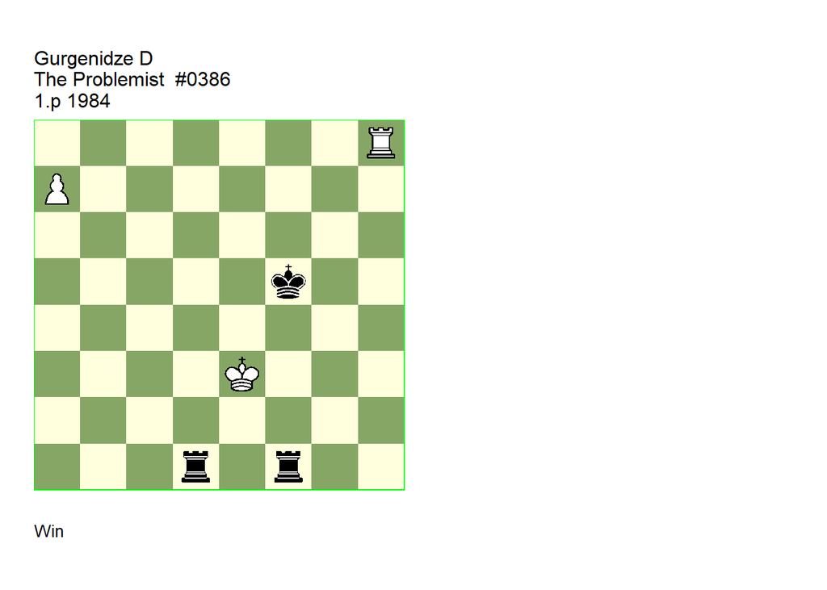

GBR: +0700.10e3f5 U1 FEN: 7R/P7/8/5k2/8/4K3/8/3r1r2 w - - 0 1

Themes 64=113 Themess 64/1-3 (EG#06219). U1: Hornecker=S HHdbIV#52200 30-6-2005. Comment: Neuenschwander=B beatochess 02/042025. **1. a8=Q** (1. Rf8+ Ke5 (1… Ke6! **BN** draws 2. a8=Q (2. Rxf1 Rd8) 2… Rde1+ 3. Kd4 Rd1+) 2. Rxf1 (2. a8=Q! **cook** NH 2… Rde1+ (2… Rfe1+ 3. Kf3 Rf1+ 4. Kg2 Rg1+ 5. Kh2 Rh1+ 6. Qxh1 Rxh1+ 7. Kxh1) 3. Kd3 Rd1+ 4. Kc4 Rc1+ 5. Kb5 Rb1+ 6. Kc6 Rfc1+ (6… Rbc1+ 7. Kd7 Rfd1+ 8. Ke7 Rc7+ 9. Ke8) 7. Kd7 Rd1+ 8. Ke7) 2… Rd8 ) **1… Rde1+! 2. Kd4 Rd1+ 3. Kc5 Rc1+ 4. Kd6 Rcd1+ 5. Ke7 Rde1+ 6. Kf7!** (6. Kf8? Ke6+) **6… Ke5+ 7. Kg6 Rg1+ 8. Kh5 Rh1+ 9. Kg4 Reg1+ 10. Kf3 Rf1+ 11. Ke3** (11. Ke2 or ) **11… Re1+ 12. Kd3 Rd1+ 13. Kc4 Rc1+ 14. Kb5 Rb1+ 15. Kc6 Rbc1+ 16. Kd7 Rcd1+ 17. Ke7 1-0**.

Date: April 3, 2025

File: Maksimovskikh1984a.pgn

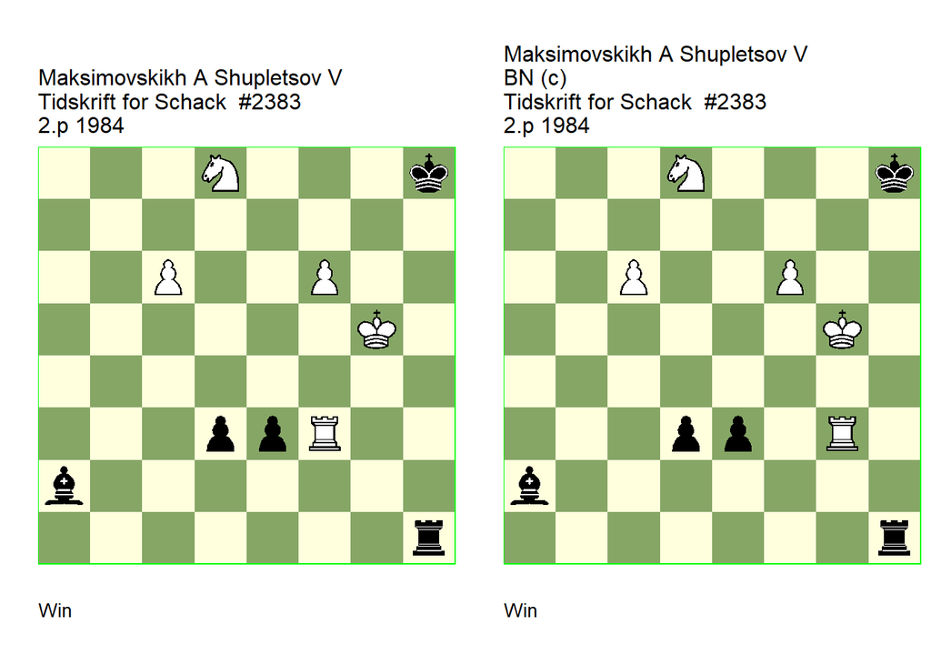

GBR: +0431.22g5h8 U1 FEN: 3N3k/8/2P2P2/6K1/8/3ppR2/b7/7r w - - 0 1

Tidskrift for Schack=5 Tidskrift for Schack/6-7 (EG#06232). U1: Van, der, Heijden=H HHdbVI 21-11-2018. **1. Rh3+!** (1. c7! **cook** HH 1… Rc1 2. Kg6 Rg1+ (2… d2 3. f7) 3. Rg3! Rxg3+ 4. Kf5 Rf3+ 5. Kg4 Rxf6 6. c8=Q) **1… Rxh3 2. c7 Rh5+! 3. Kxh5 d2 4. Nf7+! Bxf7+ 5. Kh6! d1=Q 6. c8=Q+ Bg8 7. Qb7! Bf7 8. Qa8+! Bg8 9. Qg2! Qd7 10. Qg7+! Qxg7+ 11. fxg7# 1-0**.

GBR: +0431.22g5h8 (c) FEN: 3N3k/8/2P2P2/6K1/8/3pp1R1/b7/7r w - - 0 1

correction: Neuenschwander=B beatochess 03/04/2025/ **1. Rh3+!** (1. c7? Rc1 2. Kg6 d2 3. f7 Bxf7+ 4. Nxf7+ Kg8) **1… Rxh3 2. c7 Rh5+! 3. Kxh5 d2 4. Nf7+! Bxf7+ 5. Kh6! d1=Q 6. c8=Q+ Bg8 7. Qb7! Bf7 8. Qa8+! Bg8 9. Qg2! Qd7 10. Qg7+! Qxg7+ 11. fxg7# 1-0**.

Date: April 4, 2025

File: Petrenj1983a.pgn

The version (2nd study) suffers from the same cook **1… Kd5!**.

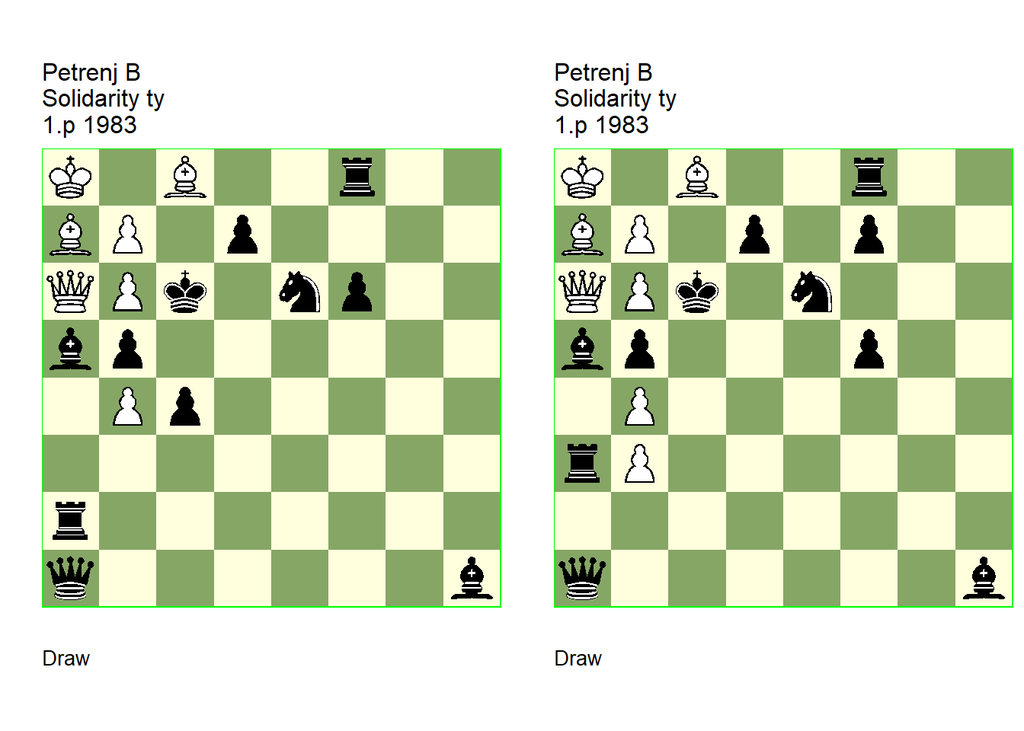

GBR: =4683.34a8c6 U3 FEN: K1B2r2/BP1p4/QPk1np2/bp6/1Pp5/8/r7/q6b w - - 0 1

(EG#06275). U3: Garcia=M HHdbV#30509 23-9-2011. **1. b8=B** (1. b8=N+? Kd6+ 2. b7+ Ke7) (1. b8=Q? Bxb4) **1… Bxb4** (1… Nc7+ 2. bxc7+ Kd5 3. Bb7+ Ke5 4. c8=Q+) (1… Kd5! **cook** MG 2. Qxb5+ Kd4+ 3. b7+ Bb6 4. Qxb6+ Kc3) **2. b7+ Kd5** (2… Rxa6 3. Bxd7+ Kd5 4. Bc6+ Kxc6) **3. Qc6+** (3. Qxb5+? Nc5 4. Qxb4 Rxc8 ) **3… dxc6 4. Bxe6+ Ke4 5. Bf5+ Kf3 6. Bg4+ Kg2 7. Bh3+ Kxh3 1/2-1/2**.

GBR: =4683.44a8c6 (v) U3 FEN: K1B2r2/BP1p1p2/QPk1n3/bp3p2/1P6/rP6/8/q6b w - - 0 1

U3: Neuenschwander=B beatochess 04/042025. **1. b8=B! Bxb4** (1… Kd5! **cook** **BN** 2. Qxb5+ Kd4+ 3. b7+ Kc3) **2. b7+ Kd5 3. Qc6+! dxc6 4. Bxe6+ Ke4 5. Bxf5+ Kf3 6. Bg4+ Kg2 7. Bh3+ Kxh3 1/2-1/2**.

### Blokhin +0412.02b5b3 (1985). Cook

Date: April 7, 2025

File: Blokhin1985a.pgn

**1. Nf3!** cooks the study.

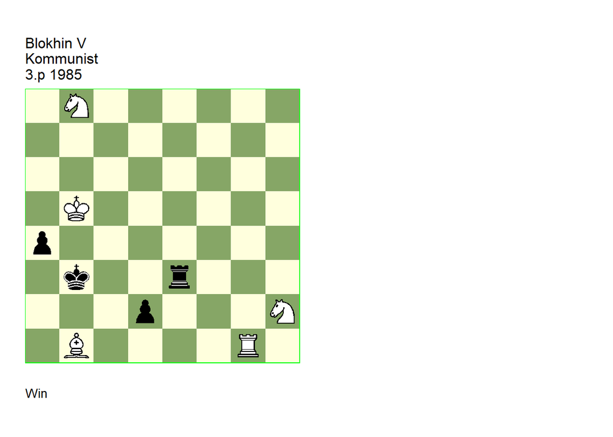

GBR: +0412.02b5b3 U1 FEN: 1N6/8/8/1K6/p7/1k2r3/3p3N/1B4R1 w - - 0 1

(EG#06290). U1: Neuenschwander=B beatochess 07/04/2025. **1. Rd1** (1. Nf3! **cook** **BN** 1… Rxf3 2. Nd7) **1… Re1 2. Ba2+!** (2. Rxd2? Rxb1) **2… Ka3 3. Rxd2 Re2! 4. Rd8!** (4. Rxe2?) **4… Rxh2 5. Bg8! Rb2+ 6. Kc4!** (6. Kc5? Rxb8 7. Rxb8) **6… Rb4+ 7. Kd5 Rb5+ 8. Ke6 Rb6+ 9. Kf7 Rb7+ 10. Nd7 1-0**.

### Frolovsky +0171.13b6h8 (1982). Cook

Date: April 8, 2025

File: Frolovsky1982a.pgn

Unfortunately, **11. Ba6!** also wins according to tablebase.

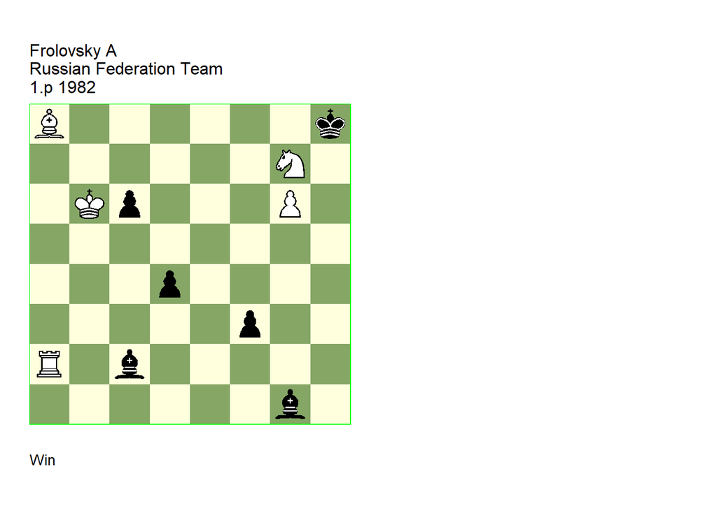

GBR: +0171.13b6h8 U2 FEN: B6k/6N1/1Kp3P1/8/3p4/5p2/R1b5/6b1 w - - 0 1

5/12.p USSR overall champ XVI 1981-1982 Bulletin Central Chess Club USSR=9(313) 1985 (EG#06324). U2: Neuenschwander=B beatochess 08/04/2025. **1. Nh5! d3+ 2. Kc7** (2. Kxc6? d2 3. Bb7 Bxg6 4. Rxd2 Bxh5) **2… Bh2+** (2… d2 3. Bxc6 Bxg6 4. Bxf3) **3. Kxc6 d2 4. Bb7 Bxg6** (4… Be4+ 5. Kb5 Bd3+ (5… Bxb7 6. Rxd2 Bc7 7. Rd7 f2 8. Rh7+ Kg8 9. Nf6+ Kf8 10. Rf7#) 6. Kb4 Bd6+ 7. Kc3 Bxg6 8. Rxd2 Be5+ 9. Kb4 Bxh5 10. Rd5 f2 11. Ba6) **5. Rxd2 Be8+ 6. Kd5 Bf7+ 7. Ke4!** (7. Kd4? f2! 8. Rxf2 Bg1!) **7… Bg6+ 8. Ke3!** (8. Kxf3? Bxh5+ 9. Kg2 Bf4 10. Rd4 Bg5 11. Rd5 Bg6 12. Rxg5 Be4+! 13. Bxe4) **8… Bg1+ 9. Kxf3 Bxh5+ 10. Kg2 Ba7 11. Be4!** (11. Ba6! **cook** **BN** DTZ 84 ) **11… Bg4 12. Kh1! Be6 13. Rd6 Bg8 14. Rd8 Bb6 15. Rb8 Bc7** eg **16. Rc8 Bd6 17. Bd5 1-0**.

### Bondarenko & Kakovin +0444.34c1a1 (1981). Dual, correction

Date: April 19, 2025

File: Bondarenko1981a.pgn

The dual on move 5 can be avoided easily.

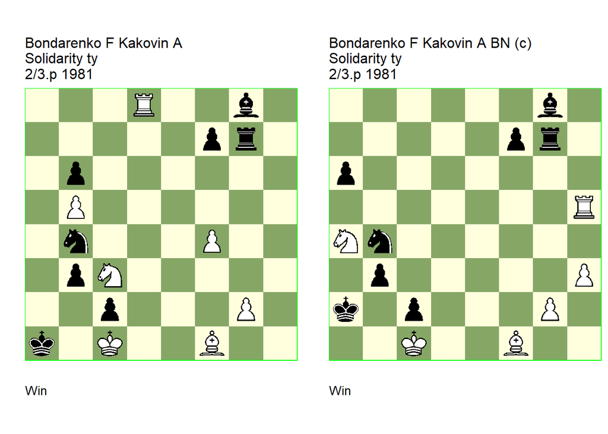

GBR: +0444.34c1a1 (U2) FEN: 3R2b1/5pr1/1p6/1P6/1n3P2/1pN5/2p3P1/k1K2B2 w - - 0 1

(EG#06262). (U2): Neuenschwander=B beatochess 19/04/2025. **1. Ra8+ Na2+ 2. Rxa2+ bxa2 3. Ne2 Bh7** (3… f5 **main** 4. Nd4 Rc7 5. Bc4 Rxc4 (5… Bxc4 **main** 6. Nxc2#) 6. Nb3#) **4. Nd4 Rg3 5. Bd3** (5. f5 **dual** **BN** 5… Bxf5 ( 5… Rc3 6. g4) 6. Bd3) **5… Rxd3** (5… Bxd3 **main** 6. Nb3#) **6. Nxc2# 1-0**.

GBR: +0444.24c1a2 (c) FEN: 6b1/5pr1/p7/7R/Nn6/1p5P/k1p3P1/2K2B2 w - - 0 1

correction: Neuenschwander=B beatochess 19/04/2025. **1. Nc3+** (1. Ra5? b2+ 2. Nxb2+ Kb3 3. Bc4+ Kc3) **1… Ka1 2. Ra5+ Na2+ 3. Rxa2+ bxa2 4. Ne2 Bh7** (4… f5 **main** 5. Nd4 Rc7 6. Bc4! Bxc4 (6… Rxc4 **main** 7. Nb3#) 7. Nxc2#) **5. Nd4 Rg3 6. Bd3! Bxd3** (6… Rxd3 **main** 7. Nxc2#) **7. Nb3# 1-0**.

### Bondarenko & Sidorov =3213.12h1g8 (1985). Cook

Date: April 19, 2025

File: Bondarenko1985a.pgn

Black wins by **Nd2** on move 2 or later.

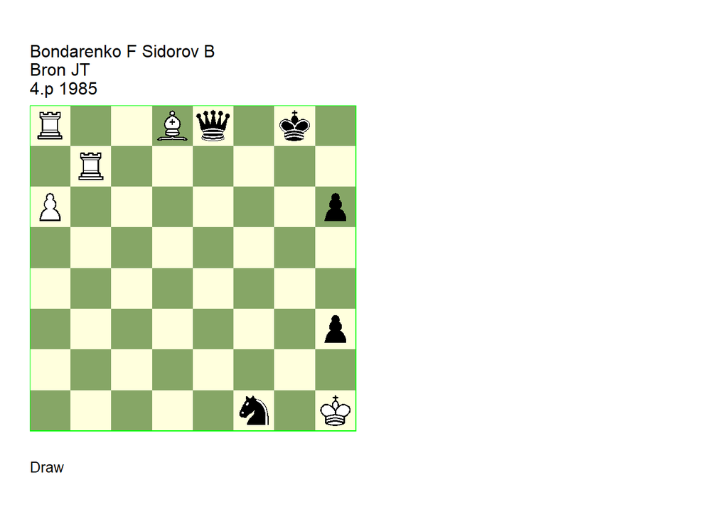

GBR: =3213.12h1g8 U3 FEN: R2Bq1k1/1R6/P6p/8/8/7p/8/5n1K w - - 0 1

(EG#06414). U3: Neuenschwander=B beatochess 19/04/2025. **1. Bb6 Qxa8 2. Ba7 Kh8** (2… Nd2! **cook** **BN** 3. Kh2 Nf3+ 4. Kg3 (4. Kxh3 Qc8+) 4… h2 5. Kg2 Ne5 6. Kxh2 Nc6) **3. Bd4+ Kg8 4. Ba7 h5 5. Kg1 h2+ 6. Kh1 Kh8 7. Bd4+ Kg8 8. Ba7 h4 9. Kg2 h3+ 10. Kh1 Kf8 11. Bc5+ Ke8 12. Ba7 Kd8 13. Bb6+ Kc8 14. Ba7 Kd8 15. Bb6+ 1/2-1/2**.

### Amiryan +4010.13g8h1 (1983). Correction

Date: April 21, 2025

File: Amiryan1983a.pgn

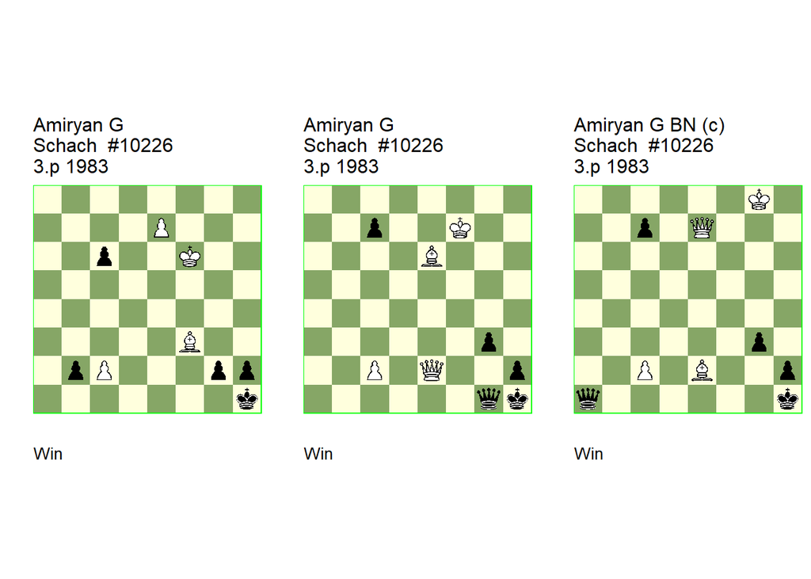

GBR: +0010.24f6h1 (v) U2 FEN: 8/4P3/2p2K2/8/8/5B2/1pP3pp/7k w - - 0 1

Schach/11 . U2: 25 Ukrainian Chess Solving Championships-8 2012. **1. e8=Q b1=Q 2. Qe2 Qg1 3. Kf7** (3. c3! **cook** c5 4. Kg5 c4 (4… Qc1+ 5. Kg4 Qg1 6. Kh3 c4 7. Bxg2+) 5. Kg4 Qf2 6. Qd1+ Qg1 7. Bxg2+ Kxg2 8. Qf3#) **3… c5 4. Ke6 c4 5. Kd5 c3 6. Ke4 Qf2 7. Qd1+ Qg1 8. Bxg2+ Kxg2 9. Qf3# 1-0**.

GBR: +4010.13f7h1 U2 FEN: 8/2p2K2/4B3/8/8/6p1/2P1Q2p/6qk w - - 0 1

Schach/11 (EG#06427). U2: Hornecker=S HHdbIII#18578 15-8-2004. **1. Bd5+ g2 2. Ke6!** (2. Kg6? c5 3. Kf5 c4 4. Bf3 (4. c3 Qf2+ 5. Qxf2) (4. Be4 Qc5+ 5. Kg4 Qc8+ 6. Kg3 Qc7+ 7. Kf2 Qc5+) 4… Qc5+) (2. Be4? c5 3. Ke6 c4 4. Kd5 (4. Kf5 Qc5+) 4… c3 5. Bf3 Qf2 6. Qd1+ Qg1) (2. Bf3? c6 3. Ke6 c5 4. Kf5 c4 5. Ke4 c3 6. Kd3 Qf2) **2… c6** (2… c5 3. Bf3!) **3. Be4! c5 4. Bf3!** (4. Kf5! **cook** NH 4… c4 5. Kg4 c3 6. Qf3! Qf2 7. Qd1+ Qg1 8. Bxg2+! Kxg2 9. Qf3#) **4… c4 5. Kd5 c3 6. Ke4 Qf2 7. Qd1+ Qg1 8. Bxg2+! Kxg2 9. Qf3# 1-0**.

GBR: +4010.13g8h1 (c) FEN: 6K1/2p1Q3/8/8/8/6p1/2P1B2p/q6k w - - 0 1

correction: Neuenschwander=B beatochess 21/04/2025. **1. Bf3+ g2 2. Qe2 Qg1** ( 2… Qa2+ 3. Kg7 Qa1+ 4. Kg6) **3. Kf7! c5 4. Ke6! c4 5. Kd5! c3 6. Ke4! Qf2 7. Qd1+ Qg1 8. Bxg2+! Kxg2 9. Qf3# 1-0**.

### Fritz +0171.11h1c21 (1984). Correction

Date: April 22, 2025

File: Fritz1984a.pgn

The correction has **9… Bd7** as the mainline, which is more consistent with the systematic movement of the study.

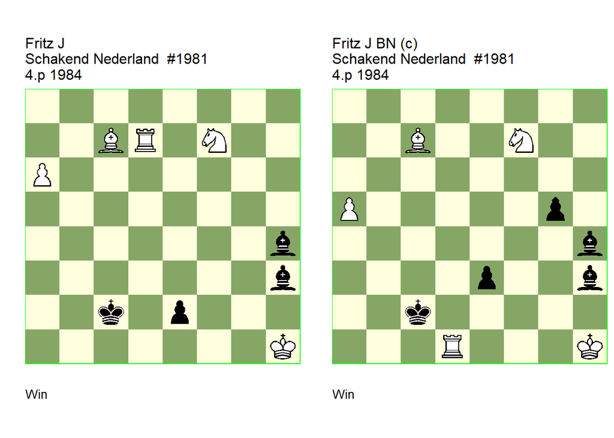

GBR: +0171.11h1c2 U2 FEN: 8/2BR1N2/P7/8/7b/7b/2k1p3/7K w - - 0 1

Schakend Nederland/11 (EG#06489). U2: Campioli=M HHdbII#46509 9-7-1998. **1. Rd2+! Kxd2 2. Ba5+ Ke3** (2… Kd3 3. a7 Bf5 4. Nd6) (2… Kd1 3. a7) **3. a7 Bg4** (3… Bf5 4. Nd6 Bg4 5. Nc4+ Kf4 6. Bd2+ Kg3 7. Ne5) **4. Ne5 Bf5 5. Nc4+** (5. Bb6+? Kf4!) (5. Bd2+? Kxd2 6. Nf3+ Ke3 7. a8=Q Be4!) **5… Kd4** (5… Kd3 6. Nd6) (5… Kf4 6. Bd2+ Kf3 7. a8=Q+ Be4 8. Ne5+) **6. Nd6 Be6 7. Nb5+ Kc5** (7… Kc4 8. Nc7) (7… Ke5 8. Bc3+ Ke4 9. a8=Q+ Bd5 10. Nd6+) **8. Nc7 e1=Q+** ( 8… Bd7 9. Na6+ Kb5 (9… Kd6 10. Bb4+ Kd5 11. a8=Q+ Bc6 12. Nc7+) 10. Nb8 Kxa5 11. a8=Q+ Kb5 12. Qa6+) **9. Bxe1 Bd7 10. Na6+** (10. Bb4+! **cook** MC 10… Kxb4 11. a8=Q) **10… Kb6 11. a8=Q Bc6+ 12. Qxc6+ Kxc6 13. Bxh4 1-0**.

GBR: +0171.12h1c2 (c) FEN: 8/2B2N2/8/P5p1/7b/4p2b/2k5/3R3K w - - 0 1

correcction: Neuenschwander=B beatochess 22/04/2025. **1. a6 e2 2. Rd2+ Kxd2 3. Ba5+ Ke3 4. a7 Bg4 5. Ne5 Bf5 6. Nc4+ Kd4 7. Nd6 Be6 8. Nb5+ Kc5 9. Nc7 Bd7** ( 9… e1=Q+ 10. Bxe1 Bd7 11. Bb4+ Kb6 12. a8=Q Bc6+ 13. Nd5+) **10. Na6+ Kb5 11. Nb8 1-0**.

### Zinar +0400.81h1g3 (1985). Cooks

Date: April 23, 2025

File: Zinar1985a.pgn

In addition to the cook on move 3, there are the obvious winning promotions to queen or bishop on move 1.

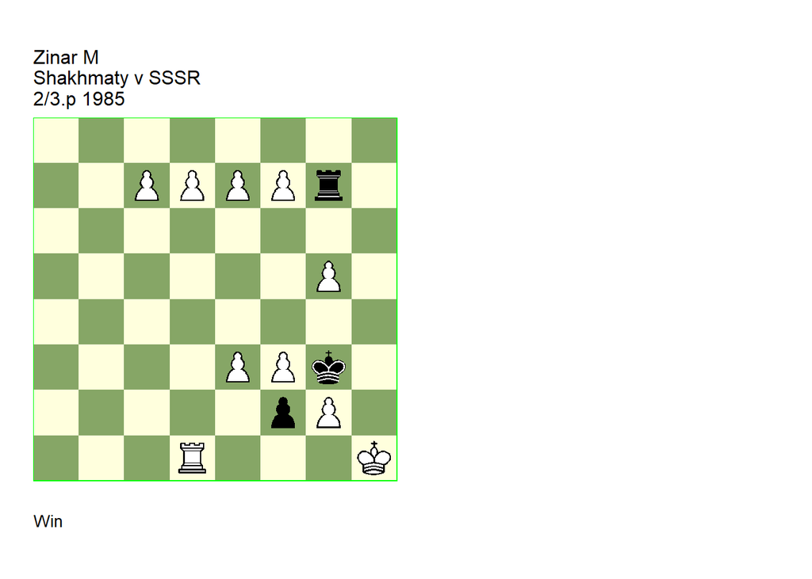

GBR: +0400.81h1g3 TT U2 FEN: 8/2PPPPr1/8/6P1/8/4PPk1/5pP1/3R3K w - - 0 1

(EG#06539). U2: Friedgood=D EG=91 3/1988. U1: Neuenschwander=B beatochess 23/04/2025. **1. f8=N** (1. g6? Rxg6 2. f8=B Rg8 3. Bg7 Rxg7) (1. f8=Q **cook** **BN** 1… Rh7+ 2. Qh6) (1. f8=B **cook** **BN** 1… Rh7+ 2. Bh6) **1… Rxg5** (1… Rg8 2. g6) **2. e8=B** (2. e8=Q? Rh5+ 3. Qxh5 f1=Q+ 4. Rxf1) **2… Rd5 3. d8=R** (3. d8=Q? Rh5+ 4. Bxh5 f1=Q+ 5. Rxf1) (3. Rf1? Rd6 4. Ng6 (4. Bg6! **cook** DF 4… Rxg6 5. Rxf2) 4… Rd1 5. Rxd1 f1=Q+ 6. Rxf1) **3… Rxd8 4. cxd8=R** (4. cxd8=Q? f1=Q+ 5. Rxf1) (4. cxd8=B? f1=Q+ 5. Rxf1) **1-0**.

### Davranyan =0000.53h1a8 (1986). Changed solution

Date: April 23, 2025

File: Davranyan1986a.pgn

The mainline should be **8… Ke6** because **8… Kc6** leads to a simple draw after **9. Ke5**.

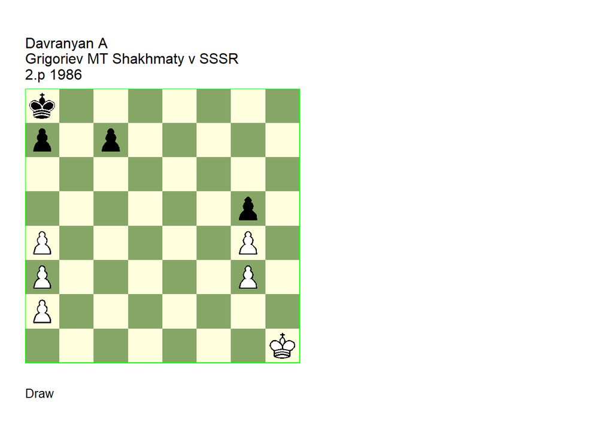

GBR: =0000.53h1a8 TT (s) FEN: k7/p1p5/8/6p1/P5P1/P5P1/P7/7K w - - 0 1

Shakhmaty v SSSR/7 (EG#06548). (s): Neuenschwander=B beatochess 23/04/2025. **1. Kg2 Kb7 2. Kf3 c5** (2… Kc6 **main** 3. Ke4 Kd6 4. Kd4 (4. Kf5? c5 5. Kxg5 Ke5 6. Kh5 c4 7. g5 c3 8. g6 Kf6 9. Kh6 c2 10. g7 c1=Q+) 4… c5+ 5. Kc4 Kc6 6. a5 Kd6 7. a6 (7. a4 or ) 7… Kc6 8. a4 Kd6 9. a5 Kc6 10. a4 Kd6 11. Kb5 Kd5) **3. Ke4 Kc6 4. Ke5! a6** (4… a5 **main** 5. Ke4 Kd6 6. Kd3 (6. Ke3 or 6… Ke5 7. Kd3) 6… Kd5 7. Kc3 c4 8. Kd2 (8. Kb2 or ) (8. Kc2? Kd4 9. Kd2 c3+ 10. Kc2 Kc4 11. Kc1 Kd3 12. Kd1 Ke3) 8… Kd4 9. Kc2 c3 10. Kb3 Kd3) **5. Ke4!** (5. a5? c4 6. Ke4 Kc5 7. a4 c3 8. Ke3 Kc4) **5… Kd6 6. a5!** (6. Ke3? Ke5!) **6… Kc6 7. a4!** (7. Kd3? Kb5 8. Kc3 Kxa5 9. Kc4 Kb6 10. Kd5 Kb5 11. a4+ Kb4 12. a5 Kb5 13. a3 c4 14. Kd4 Kxa5) **7… Kd6 8. a3!** (8. Ke3? Ke5!) **8… Kc6** This should be the sideline. (8… Ke6! **main** line 9. Kd3 Kd5 10. Kc3 c4 11. Kb4 Kd4) **9. Kd3!** (9. Ke5! **BN** ) **9… Kd5 10. Kc3 c4 11. Kb4 Kd4 1/2-1/2**.

### Balanovsky +0000.55b8h4 (1986). Correction

Date: April 23, 2025

File: Balanovsky1986a.pgn

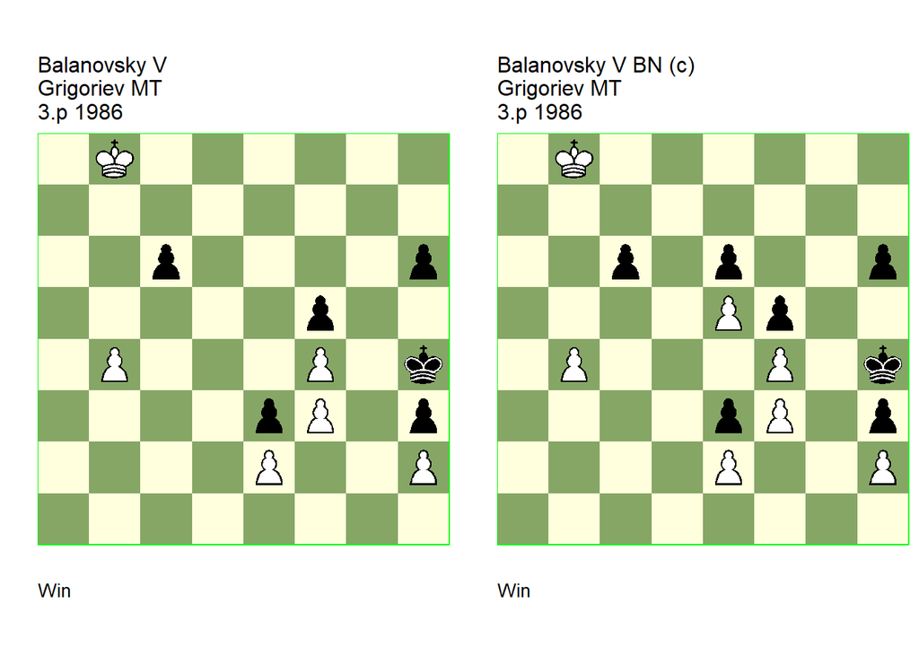

GBR: +0000.55b8h4 TT U3 FEN: 1K6/8/2p4p/5p2/1P3P1k/4pP1p/4P2P/8 w - - 0 1

Shakhmaty v SSSR/7 (EG#06549). U3: Schach Report/12 1996. **1. Ka8!** (1. Ka7? Kh5 (1… h5 2. Ka6) 2. Ka6 Kh4! 3. Ka5 Kh5! 4. Ka4 Kh4! 5. Kb3 (5. Ka3 c5 6. b5 c4 7. b6 c3 8. b7 c2 9. b8=Q c1=Q+) 5… c5! 6. b5 c4+ 7. Kc3 h5 ) (1. Kc7? c5! 2. b5 c4 3. b6 c3 4. b7 c2 5. b8=Q c1=Q+ 6. Kd7 Qd2+) **1… Kh5!** (1… c5 2. b5) **2. Ka7! Kh4** (2… Kg6! **cook** 3. Ka6 c5 4. bxc5 ( 4. b5 c4) 4… Kh5 5. c6 Kh4 6. c7 h5 7. c8=Q) **3. Ka6 Kh5 4. Ka5 Kh4 5. Ka4 Kh5** (5… h5 6. Ka5) **6. Kb3! Kh4** (6… c5 **main** 7. b5 c4+ 8. Kc3 Kh4 9. b6 h5 10. Kd4 c3 11. b7 c2 12. b8=Q c1=Q 13. Qd8#) **7. Kc3** (7. Kc2 or ) **7… h5 8. Kd3** (8. Kd4 or ) **8… c5 9. Kxe3 c4 10. Kd2! c3+ 11. Kc1 c2 12. e4 1-0**.

GBR: +0000.55b8h4 TT (c) FEN: 1K6/8/2p1p2p/4Pp2/1P3P1k/4pP1p/4P2P/8 w - - 0 1

correction: Neuenschwander=B beatochess 23/04/2025. **1. Ka8!** (1. Ka7? Kh5 2. Ka6 Kh4 3. Ka5 Kh5 4. Ka4 Kh4 5. Kb3 (5. Ka3 c5 6. b5 c4 7. b6 c3 8. b7 c2 9. Kb2 h5 10. b8=Q c1=Q+ 11. Kxc1) 5… c5 6. b5 c4+) **1… Kh5? 2. Ka7 Kh4** ( 2… Kg6 3. Ka6 c5 4. b5 c4 5. b6 c3 6. b7 c2 7. b8=Q c1=Q 8. Qg8+ Kh5 9. Qxe6) **3. Ka6 Kh5 4. Ka5 Kh4 5. Ka4 Kh5 6. Kb3 Kh4** (6… c5 7. b5 c4+ 8. Kc3 Kh4 9. b6 h5 10. Kd4 c3 11. b7 c2 12. b8=Q c1=Q 13. Qd8#) **7. Kc3** (7. Kc2 or ) **7… h5 8. Kd3** (8. Kd4 or ) **8… c5 9. Kxe3 c4 10. Kd2 c3+ 11. Kc1 c2 12. e4 1-0**.

### Yarmonov +0500.25b2d8 (1986). Cook, version

Date: April 26, 2025

File: Yarmonov1986a.pgn

**1. Rh8+** cooks the study. The version is a bit richer in content (with the thematic rook sacrifices at moves 4 and 5).

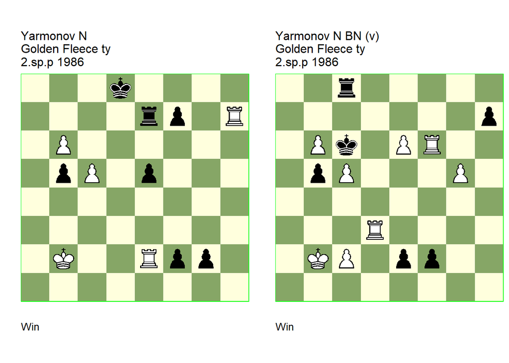

GBR: +0500.25b2d8 U1 FEN: 3k4/4rp1R/1P6/1pP1p3/8/8/1K2Rpp1/8 w - - 0 1

(EG#06617). U1: Neuenschwander=B beatochess 25/04/2025. **1. c6** (1. Rh8+ **cook** **BN** 1… Kd7 (1… Re8 2. Rxe8+ Kxe8 3. b7) 2. b7 f1=Q 3. Rd2+ Ke6 4. b8=Q) **1… Re8 2. Rxf7 f1=Q 3. Rd2+ Kc8 4. Rc7+ Kb8 5. Re7 Qf8 6. Rd8+ Rxd8 7. c7+ Ka8 8. b7+ Ka7 9. b8=Q+ Rxb8 10. c8=N+ Ka6 11. Ra7# 1-0**.

GBR: +0500.54b2c6 (v) FEN: 2r5/7p/1Pk1PR2/1pP3P1/8/3R4/1KP1pp2/8 w - - 0 1

(v): Neuenschwander=B beatochess 26/04/2025. **1. e7+** (1. Rd8? e1=Q 2. Rxc8+ Kd5 3. Rf5+ (3. Rd8+ Kxc5) ) **1… Kb7 2. e8=Q** (2. Rd7+? Kb8 3. b7 e1=Q 4. bxc8=Q+ Kxc8 5. Rd8+ Kc7 6. e8=Q Qb4+ 7. Kc1 Qe1+) **2… Rxe8 3. Rf7+! Kb8 4. c6 f1=Q** (4… e1=Q 5. Rd8+! Rxd8 6. c7+ Kc8 7. b7+ Kxb7 8. cxd8=Q+) **5. Re7** ( 5. Rdd7? Qb1+) **5… Qf8** (5… e1=Q 6. Rd8+! Rxd8 7. c7+ Kc8 8. b7+ Kxb7 9. cxd8=Q+ Qxe7 10. Qxe7+ Kc6 11. Qxh7) **6. Rd8+! Rxd8 7. c7+ Ka8 8. b7+ Ka7 9. b8=Q+ Rxb8 10. c8=N+! Ka6** (10… Ka8 **main** 11. Ra7#) **11. Ra7# 1-0**.

### Kuruoglu +0310.44b5f5 (1986). Corrected solution

Date: April 27, 2025

File: Kuruoglu1986a.pgn

The study’s solution in **HHdbVI** is not correct. The mainline is obviously **4. g4+!**.

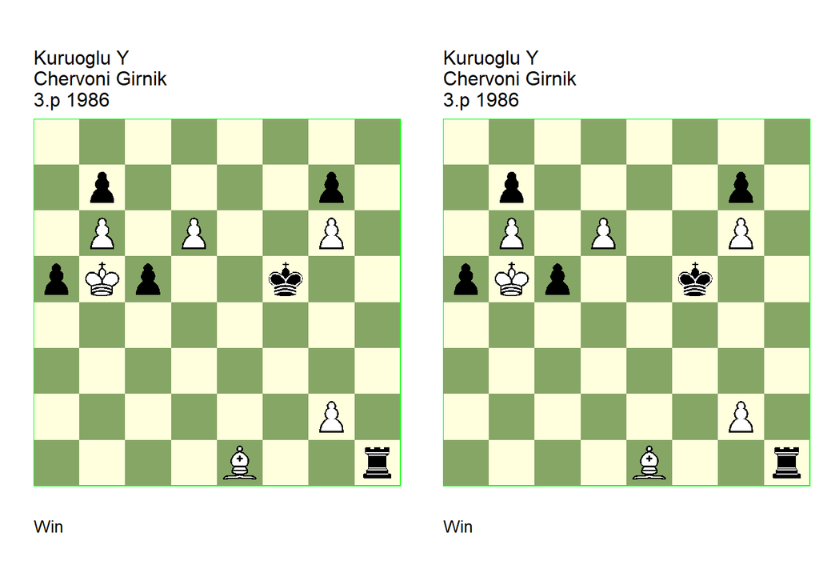

GBR: +0310.44b5f5 FEN: 8/1p4p1/1P1P2P1/pKp2k2/8/8/6P1/4B2r w - - 0 1

(EG#06650). **1. d7 Rh8 2. Bh4 a4 3. Kc4** (3. Kxa4? Rxh4+ 4. Kb5 Rd4) (3. Kxc5? a3) **3… Rxh4+ 4. Kxc5 a3 5. d8=Q a2 6. Qd5+ Kxg6 7. Qxa2 1-0**.

GBR: +0310.44b5f5 (s) FEN: 8/1p4p1/1P1P2P1/pKp2k2/8/8/6P1/4B2r w - - 0 1

(EG#06650). (s): Neuenschwander=B beatochess 27/4/2025. **1. d7 Rh8 2. Bh4 a4 3. Kc4** (3. Kxa4? Rxh4+ 4. Kb5 Rd4) (3. Kxc5? a3) **3… Rxh4+ 4. g4+! Rxg4+ 5. Kxc5 a3 6. d8=Q 1-0**.

Date: April 27, 2025

File: Roiko1986.pgn

The study is a mistery. What is interesting in this study? The position is totally won with the white passed pawn on the queen side.

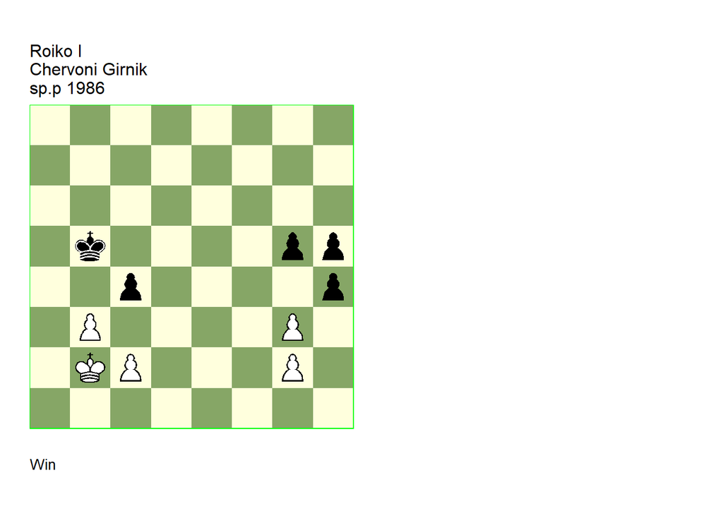

GBR: +0000.44b2b5 U2 FEN: 8/8/8/1k4pp/2p4p/1P4P1/1KP3P1/8 w - - 0 1

(EG#06651). U2: Garcia=M HHdbV#27518 23-9-2011. **1. gxh4 gxh4 2. Kc3** (2. Ka3! **cook** MG ) **2… cxb3 3. Kxb3** (3. cxb3? h3 4. gxh3 h4 5. Kd3 Kb4 6. Ke3 Kxb3 7. Kf3 Kc4 8. Kg4 Kd5 9. Kxh4 Ke6 10. Kg5 Kf7) **3… Kc5 4. Kc3 Kd5 5. Kd3** (5. Kb4? Ke4) **5… Ke5 6. Ke3 Kf5 7. Kf3 Ke5 8. c4 Kd4 9. Kf4 Kxc4 10. Kg5 h3 11. gxh3 Kd5 12. Kxh5 Ke6 13. Kg6 1-0**.

### Dobrescu +0751.21h1g8 (1984). Cook

Date: April 28, 2025

File: Dobrescu1984a.pgn

**8. Rh6+** cooks the study.

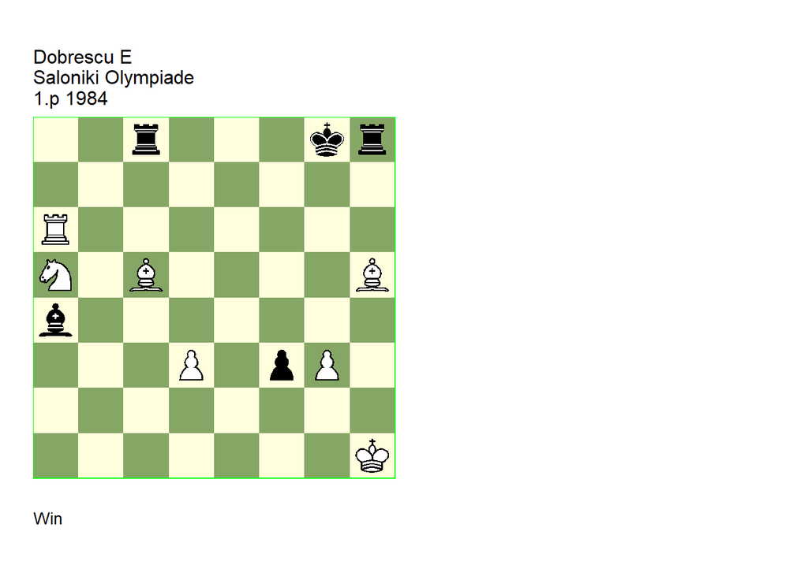

GBR: +0751.21h1g8 U2 FEN: 2r3kr/8/R7/N1B4B/b7/3P1pP1/8/7K w - - 0 1

(EG#06664). U2: Neuenschwander=B beatochess 28/04/2025. **1. Rg6+ Kf7 2. Rg5+!** (2. Rh6+? Kg7 3. Rxh8 Rxc5 4. Ra8 Rxh5+ 5. Kg1 Rh3 6. Kf2 Bd1) **2… Kf6 3. Rd5 Ke6** (3… Bd1 4. g4) **4. Rd6+ Ke7 5. Nc6+!** (5. Rh6+? Rxc5 6. Rxh8 Rc1+ 7. Kh2 f2 8. Be2 Re1) **5… Bxc6 6. Rxc6+ Kd7 7. Rd6+ Ke7!** (7… Kc7 8. Rd5) **8. Rd5+!** (8. Rh6+? Rxc5 9. Rxh8 Rc1+ 10. Kh2 f2 11. Be2 (11. Rh7+! **cook** 11… Ke6 (11… Kd6 12. Be2 Re1 13. Rf7 Rxe2 14. Kh3) 12. Be2 Re1 13. Bg4+ Kf6 14. Bh3) 11… Re1 12. Bf1 Rxf1 13. Kg2 Rd1) **8… Ke6 9. Rg5 Kf6 10. Rg6+!** (10. Be3? Rce8 11. Rg6+ (11. Bd2 Re2 12. Rg6+ Ke7 13. Bb4+ Kd7) 11… Kf7 12. Rh6+ Kg7 13. Rxh8 Rxe3 14. Rd8 (14. Re8 f2 15. Kg2 Rxg3+) 14… Re1+) **10… Kf7 11. Rh6+! Kg7 12. Rxh8 Rxc5 13. Rd8! Rc1+** (13… Rxh5+ 14. Kg1 Rf5 15. Kf2) **14. Kh2 f2 15. Be2 Re1 16. Bf1! Rxf1 17. Kg2 1-0**.

### Kalandadze +0800.11h1f6 (1984). Cook, correction

Date: April 28, 2025

File: Kalandadze1984b.pgn

**3. R8xf5! a1=Q 4. Rf4!** cooks the study. In the correction, the white rook is not en prise, and there is the rook switchback to the starting square c1.

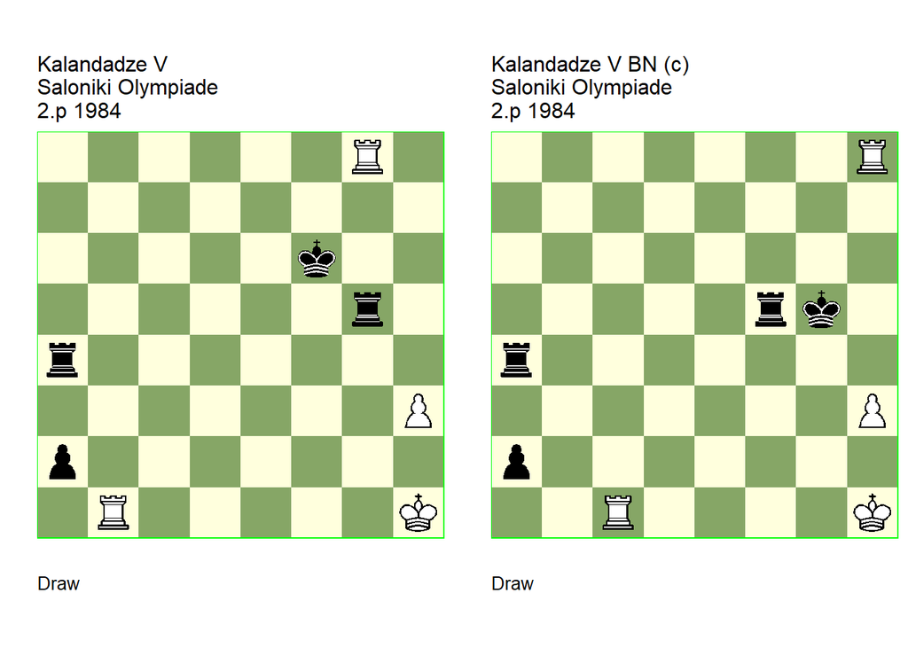

GBR: =0800.11h1f6 U2 FEN: 6R1/8/5k2/6r1/r7/7P/p7/1R5K w - - 0 1

(EG#06665). U2: Neuenschwander=B beatochess 28/04/2025. **1. Rf1+ Rf5 2. Rf8+ Ke6 3. Re1+** (3. R8xf5! **cook** **BN** 3… a1=Q 4. Rf4! Qa2 5. Rxa4 Qxa4) **3… Re5 4. Re8+ Kd6 5. Rd1+ Rd5 6. Rd8+ Kc6 7. Rc1+ Rc5 8. Rc8+ Kb6 9. R8xc5 a1=Q 10. Rc6+ Kb5 11. Rc8 Qe5 12. Rb1+ Rb4 13. Rxb4+! Kxb4 14. Rg8! Qd5+ 15. Rg2 1/2-1/2**.

GBR: =0800.11h1g5 (c) FEN: 7R/8/8/5rk1/r7/7P/p7/2R4K w - - 0 1

correction: Neuenschwander=B beatochess 28/04/2025. **1. Rg1+** (1. Rg8+? Kh4 2. Rh8+ Kg3 3. Ra1 Rb5) **1… Kf6 2. Rf8+ Ke6 3. Re1+ Re5 4. Re8+ Kd6 5. Rd1+ Rd5 6. Rd8+ Kc6 7. Rc1+ Rc5 8. Rc8+ Kb6 9. R8xc5 a1=Q 10. Rc6+** (10. Rc8 Qe5 11. Rb1+ Ka7) **10… Kb5 11. Rc8 Qe5 12. Rb1+ Rb4 13. Rxb4+ Kxb4 14. Rg8 1/2-1/2**.

### Liburkin +4044.13h4b6 (1940). Cook

Date: April 30, 2025

File: Liburkin1940a.pgn

The correction is incorrect due to **10. Be6+!**. The idea of a retrospective tourney of the 1940/41 studies of “Shakhmaty v SSSR” was critized by John Roycroft (EG no. 91, p. 346):

> “For me this tourney combines eerie nostalgia with the sacrilege of disturbing a graveyard. We can enjoy and appreciate classic studies and great names alongside unknowns, but to pit the dead against each other, and against the living, and to award them prizes, lacks taste.”

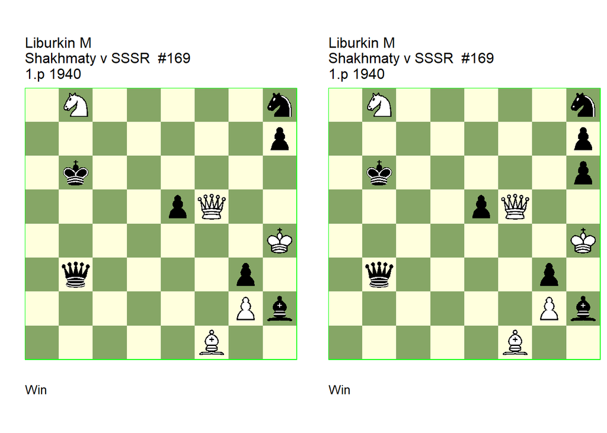

GBR: +4044.13h4b6 U3 FEN: 1N5n/7p/1k6/4pQ2/7K/1q4p1/6Pb/5B2 w - - 0 1

Shakhmaty v SSSR/8 (EG#06719). U3: Falk=L Hildebrand=A 64 Shakhmatnoye Obozrenye=3(698) 2/1984. **1. Qf6+ Kb7! 2. Qxh8 Qa4+!** (2… Qb4+! **cook** LF/AH 3. Kh3 Qd6 4. Ba6+ Kb6 5. Qc8 Qh6+) **3. Kh3 Qa8! 4. Ba6+ Ka7 5. Qg7+ Kxb8 6. Qxe5+ Ka7 7. Qa5! h6** (7… Qf8 8. Be2+ Kb7 (8… Kb8 9. Qb6+) 9. Bf3+ ) (7… Bg1 8. Be2+ Kb8 9. Qe5+ Ka7 10. Qa1+) **8. Bc8+ Kb8 9. Qd8 h5 10. Ba6+ Ka7 11. Qa5! h4 12. Bc8+ Kb8 13. Qd8! Bg1 14. Bg4+ Ka7 15. Qa5+ Kb8 16. Qe5+ Ka7 17. Qa1+ Kb8 18. Qxg1 1-0**.

GBR: +4044.14h4b6 (c) U2 FEN: 1N5n/7p/1k5p/4pQ2/7K/1q4p1/6Pb/5B2 w - - 0 1

Shakhmaty v SSSR/8. correction: Kuznetsov=AG 64 Shakhmatnoye Obozrenye=11(778) 6/1987. U2: Neuenschwander=B beatochess 30/04/2025. **1. Qf6+ Kb7** (1… Ka7 2. Nc6+ Kb6 3. Nd4+) (1… Kc7 2. Na6+ Kc8 3. Qxh8+ Kd7 4. Nc5+) **2. Qxh8 Qa4+** ( 2… Qb4+ 3. Kh3 Qd6 4. Ba6+ Kb6 5. Qc8) **3. Kh3 Qa8 4. Ba6+ Ka7 5. Qg7+ Kxb8 6. Qxe5+ Ka7 7. Qa5! h5** (7… Qf8 8. Bc4+ Kb7 (8… Kb8 9. Qb6+) 9. Bd5+ Kb8 10. Qa8+) (7… Bg1 8. Be2+ Kb8 9. Qe5+ Ka7 10. Qa1+ Kb8 11. Qxg1) **8. Bc8+ Kb8 9. Qd8 h4** (9… Qa1 10. Be6+ Kb7 11. Bd5+ Ka7 12. Qa8+) **10. Ba6+** (10. Be6+! **cook** **BN** 10… Ka7 11. Qa5+ Kb8 12. Qb6+ Qb7 13. Qd8+ Ka7 14. Bd5 Qb4 15. Qc7+ Ka6 16. Bc4+) **10… Ka7 11. Qa5 h6 12. Bc8+ Kb8 13. Qd8 h5 14. Ba6+ Ka7 15. Qa5 Bg1 16. Be2+ Kb8 17. Qe5+ Ka7 18. Qa1+ Kb8 19. Qxg1 1-0**.

## Miscellaneous

### Gurvich +1008.01a7h1 (1927). Cook, correction (Hergert)

Date: March 21, 2025

File: Gurvich1927a.pgn

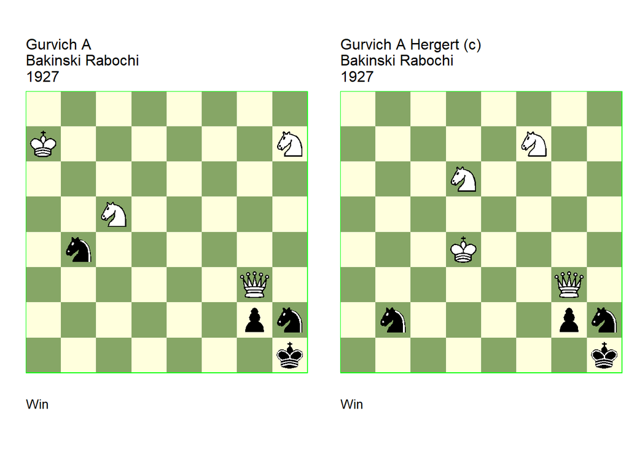

GBR: +1008.01a7h1 U2 FEN: 8/K6N/8/2N5/1n6/6Q1/6pn/7k w - - 0 1

U2: Hergert=V beatochess 21/03/2025. **1. Ne4! Nd3!** (1… g1=Q+ 2. Nf2+) **2. Qf2!** (2. Qxd3 **cook** VH 2… g1=Q+ 3. Ka6 DTZ 83 ) **2… Nxf2** (2… g1=Q 3. Ng3+) **3. Ng3+! Kg1 4. Ng5! Nhg4** (4… Nfg4 **main** 5. Nh3#) **5. Nf3# 1-0**.

GBR: +1008.01d4h1 (c) FEN: 8/5N2/3N4/8/3K4/6Q1/1n4pn/7k w - - 0 1

correction: Hergert=V beatochess 21/03/2025. **1. Ne4 Nd1 2. Qf2! Nxf2 3. Ng3+ Kg1 4. Ng5 1-0**.